# SciPy

## 目录

### 1. **SciPy 101**

### 2. **内部插值**

1. 简单例子
2. 金融案例

### 3. **数值积分**

1. 简单例子
2. 金融案例

### 4. **统筹规划**

1. 简单例子
2. 金融案例

### 5. **有限差分**

1. 简单例子
2. 金融案例

### 6. **线性回归**

1. 简单例子
2. 金融案例

### **SciPy Cheatsheet**

I can prove anything by statistics except the truth.

— George Canning

# 1. SciPy 101

回到目录

**SciPy** 是 **Sci**entific **Py**thon 的缩写，顾名思义它是 Python 里处理科学计算 (scientific computing) 的工具包，其官网是 https://www.scipy.org/

在使用 scipy 之前，需要引进它，语法如下：

```python
import scipy
```

这样你就可以用 scipy 里面所有的内置方法 (build-in methods) 了，比如插值、积分和优化。

```
scipy.interpolate
scipy.integrate
scipy.optimize
```

在 scipy 中，通常我们给 `scipy + 子工具包`一起起个别名，比如：

```
import scipy.interpolate as spi
import scipy.integrate as sci
import scipy.optimize as spo
import scipy.sparse as sp
import scipy.sparse.linalg as sla
```

这样所有出现 scipy 的地方都可以用 sp 替代。

首先引入其他需要的工具包，如 `numpy`, `pandas` 和 `matplotlib`。

```python
import numpy as np
import pandas as pd
from scipy.stats import norm
import matplotlib as mpl
import matplotlib.pyplot as plt
%matplotlib inline
mpl.rcParams['font.sans-serif'] = ['Microsoft YaHei']
mpl.rcParams['axes.unicode_minus'] = False

np.random.seed(1031)
dt_hex = '#2B4750'    # dark teal,  RGB = 43,71,80
r_hex = '#DC2624'     # red,        RGB = 220,38,36
g_hex = '#649E7D'     # green,      RGB = 100,158,125
tl_hex = '#45A0A2'    # teal,       RGB = 69,160,162
tn_hex = '#C89F91'    # tan,        RGB = 200,159,145
```

对于以上每一个知识点，我们用一个简单例子和一个金融相关的例子来讲解：

# 2. 内部插值

回到目录

在 scipy 中有个专门的函数 `scipy.interpolate` 是用来插值的，首先引进它并记为 `spi`。

```python
import scipy.interpolate as spi
```

### 2.1 简单例子

回到章首

给定一组 $(x_i, y_i)$，其中 $i = 1, 2, ..., n$，而且 $x_i$ 是有序的，称为**标准点**。插值就是对于任何新点 $x_{\text{new}}$，计算出对应的 $y_{\text{new}}$。换句话来说，插值就是在标准点之间建立分段函数 (piecewise function)，把它们连起来。这样给定任意连续 $x$ 值，带入函数就能计算出任意连续 $y$ 值。

### 线性插值

首先定义 $x$ 和函数 $f(x) = \sin(x) + 0.5x$：

```python
x = np.linspace(-2 * np.pi, 2 * np.pi, 11)
f = lambda x: np.sin(x) + 0.5 * x
f(x)
```

```
array([-3.14159265, -1.56221761, -1.29717034, -1.84442231, -1.57937505,
        0.        ,  1.57937505,  1.84442231,  1.29717034,  1.56221761,
        3.14159265])
```

接下来介绍 `scipy.interpolate` 里面两大杀器：`splrep` 和 `splev`。

观察两个函数的名称，发现

- 它们都是以 `spl` 开头，全称 spline (样条)，可以理解这两个函数都和样条有关。
- 它们分别以 `rep` 和 `ev` 结尾，意思是：
  - `rep`：**rep**resentation 的缩写，那么 `splrep` 其实生成的是一个「表示样条的对象」
  - `ev`：**ev**aluation 的缩写，那么 `splev` 其实用于「在样条上估值」

`splrep` 和 `splev` 像是组合拳 (one two punch)

- 前者将 $x, y$ 和插值方式转换成「样条对象」`tck`
- 后者利用它在 $x_{\text{new}}$ 上生成 $y_{\text{new}}$

首先运行 `splrep` 函数, 它的三个参数分别是:

- `x`: 有序的自变量
- `f(x)`: 与自变量一一对应的变量
- `k`: 多项式的阶数，`k` 只能设定在 1 和 5 之间，`k = 1` 代表线性

```python
tck = spi.splrep( x, f(x), k=1 )
tck
```

```
(array([-6.28318531, -6.28318531, -5.02654825, -3.76991118, -2.51327412,
        -1.25663706,  0.        ,  1.25663706,  2.51327412,  3.76991118,
         5.02654825,  6.28318531,  6.28318531]),
 array([-3.14159265, -1.56221761, -1.29717034, -1.84442231, -1.57937505,
         0.        ,  1.57937505,  1.84442231,  1.29717034,  1.56221761,
         3.14159265,  0.        ,  0.        ]),
 1)
```

`tck` 就是样条对象，以元组形式返回，`tck` 这名字看起来很奇怪，实际指的是元组 `(t, c, k)` 里的三元素：

- `t` - vector of knots (节点)
- `c` - spline cofficients (系数)
- `k` - degree of spline (阶数)

根据结果，`tck` 包含两个 `numpy array` 和一个标量 1，其中

- 第一个 `array` 是**节点**，即标准点，注意到一开始 `x` 只有 11 个，但现在是 13 个，首尾往外补了 `x[0]` 和 `x[-1]`
- 第二个 `array` 是**系数**，注意它就是 `y` 在尾部补了两个 0
- 标量 1 是**阶数**，因为在调用 `splrep` 时就把 `k` 设成 1

用 `PPoly.from_spline` 来查看每个分段函数的系数

- 首先创建一个**多项式对象** `pp`
- 再用 `.c` 来看系数 (`.T` 将系数数组转置，打印出来偏于检查)

```python
pp = spi.PPoly.from_spline(tck)
pp.c.T
```

```
array([[ 1.25682673, -3.14159265],
       [ 1.25682673, -3.14159265],
       [ 0.21091791, -1.56221761],
       [-0.43548928, -1.29717034],
       [ 0.21091791, -1.84442231],
       [ 1.25682673, -1.57937505],
       [ 1.25682673,  0.        ],
       [ 0.21091791,  1.57937505],
       [-0.43548928,  1.84442231],
       [ 0.21091791,  1.29717034],
       [ 1.25682673,  1.56221761],
       [ 1.25682673,  3.14159265]])
```

`tck` 的系数数组里有 13 个元素，而上面数组大小是 (12, 2)，12 表示 12 段，2 表示每段线性函数由 2 个系数确定。

把 `x` 和 `tck` 丢进 `splev` 函数，我们可以插出在 `x` 点对应的值 `iy`。

```python
iy = spi.splev( x, tck )
iy
```

```
array([-3.14159265, -1.56221761, -1.29717034, -1.84442231, -1.57937505,
        0.        ,  1.57937505,  1.84442231,  1.29717034,  1.56221761,
        3.14159265])
```

使用 `splev` 需要设定两个参数，它们分别是:

- `x`: 有序的自变量
- `tck`: `splrep(x, f(x), k=1)` 的结果

以上所有的内容用下图来总结：

[figure not shown]

我们用 **`Matplotlib`** 来可视化插值的 `iy` 和原函数 `f(x)`，发现 `iy` 都在函数 `f(x)` 上。

*Matplotlib 是之后的课题，现在读者可忽略其细节。*

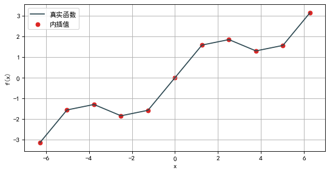

```python
plt.figure(figsize=(8,4), dpi=80)
plt.plot( x, f(x), color=dt_hex, label='真实函数' )
plt.scatter( x, iy, color =r_hex, label='内插值' )
plt.legend( loc=0 )
plt.grid(True)
plt.xlabel('x')
plt.ylabel('f(x)')
plt.show()
```

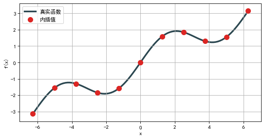

```python
plt.figure(figsize=(8,4), dpi=80)
x_ = np.linspace(-2*np.pi, 2*np.pi, 100)
plt.plot( x_, f(x_), color=dt_hex, linewidth=3, label='真实函数', zorder=1 )
plt.scatter( x, iy, 80, color =r_hex, label='内插值', zorder=2 )
plt.legend( loc=0 )
plt.grid(True)
plt.xlabel('x')
plt.ylabel('f(x)')
plt.show()
```

除了可视化，我们还可以用具体的数值结果来评估插值的效果：

- 用 `allclose` 的结果都是 `True` 证明插值和原函数值完全吻合
- 用均方误差 (mean square error, MSE) 得到 0.0 也证明插值和原函数值完全吻合

```python
np.allclose(f(x), iy)
```

```
True
```

```python
np.sum((f(x) - iy) ** 2) / len(x)
```

```
0.0
```

到目前为止，我们做的是在「标准点 `x`」上插值，那得到的结果当然等于「标准点 `y`」了。这种插值意义不大，但举这个例子只想让大家

- 明晰 `splrep` 和 `splev` 是怎么运作的
- 如何可视化插出来的值和原函数的值
- 如何用 `allclose` 来评估插值和原函数值之间的差异

一旦打好这些基础，接下来就可以看更复杂的情况了。

```python
xd = np.linspace( 1.0, 3.0, 50 )
iyd = spi.splev( xd, tck )
```

[figure not shown]

```python
fig = plt.figure(figsize=(8,4), dpi=80)
x = np.linspace(-2*np.pi, 2*np.pi, 100)

ax1 = fig.add_axes([0.05, 0.05, 0.9, 0.9])
ax1.plot( x, f(x), color=dt_hex, linewidth=3 )
ax1.grid(True)
ax1.set_xlabel('x')
ax1.set_ylabel('f(x)')
ax1.set_title(r'定义域 $[-\pi, \pi]$')

ax2 = fig.add_axes([0.55, 0.2, 0.15, 0.15])
ax2.plot( xd, f(xd), color=dt_hex, linewidth=3 )
ax2.set_title(r'定义域 $[1, 3]$')

plt.show()
```

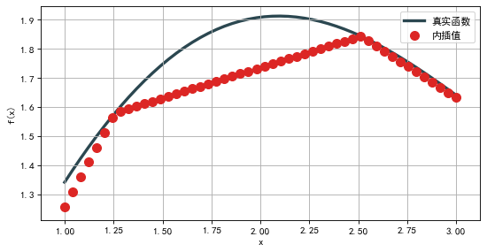

```python
plt.figure(figsize=(8,4), dpi=80)
plt.plot( xd, f(xd), color=dt_hex, linewidth=3, label='真实函数', zorder=1 )
plt.scatter( xd, iyd, 80, color =r_hex, label='内插值', zorder=2 )
plt.legend( loc=0 )
plt.grid(True)
plt.xlabel('x')
plt.ylabel('f(x)')
plt.show()
```

```python
np.allclose(f(xd), iyd)
```

```
False
```

```python
np.sum((f(xd) - iyd) ** 2) / len(xd)
```

```
0.011206417290260647
```

结果为什么会这么差呢？原因就是 `tck` 用的是 11 个「标准点 `x`」建出来的，标准点太稀疏用分段线性函数来差值效果不会太好。那我们试试分段三次样条函数。

### 一元三次条插值

线性插值中每段的函数是线性函数，即一次多项式函数，一元三次条 (cubis-spline) 插值每段的函数是三次多项式函数。

使用一元三次条插值的步骤和上面一样，只需要把 `k` 设为 3。

```python
tck = spi.splrep( x, f(x), k=3 )
iyd = spi.splev( xd, tck )
```

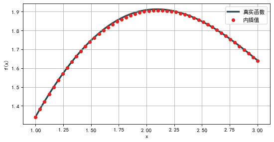

```python
plt.figure(figsize=(8,4), dpi=80)
plt.plot( xd, f(xd), color=dt_hex, linewidth=3, label='真实函数', zorder=1 )
plt.scatter( xd, iyd, 30, color =r_hex, label='内插值', zorder=2 )
plt.legend( loc=0 )
plt.grid(True)
plt.xlabel('x')
plt.ylabel('f(x)')
plt.show()
```

```python
np.allclose(f(xd), iyd)
```

```
False
```

```python
np.sum((f(xd) - iyd) ** 2) / len(xd)
```

```
1.1349319851436252e-08
```

### 2.2 金融案例

回到章首

### 插值折现因子来计算远期利率。

在金融市场中，每个货币都有自己相对应的折现曲线，简单来说，就是在「标准日期」上一组折现因子 (discount factor) 或零息利率 (zero rate)。用 **`pandas`** 来读取 **2019-04-01** 这一天的折现曲线。

```python
curve = pd.read_excel('CNY zero curve.xlsx')
curve
```

|  | 日期 | 折现因子 | 零息利率 (%) |
| --- | --- | --- | --- |
| 0 | 2019-04-03 | 0.999905 | 1.726744 |
| 1 | 2019-04-10 | 0.999565 | 1.764049 |
| 2 | 2019-05-03 | 0.998324 | 1.913496 |
| 3 | 2019-06-03 | 0.996434 | 2.069661 |
| 4 | 2019-07-03 | 0.993978 | 2.170469 |
| 5 | 2019-10-03 | 0.985531 | 2.475450 |
| 6 | 2020-01-03 | 0.978066 | 2.922324 |
| 7 | 2020-04-03 | 0.970684 | 3.051187 |
| 8 | 2021-04-03 | 0.942104 | 3.269799 |

第一个点的日期是 **2019-04-03**，称为即期日，从第二个点开始的日期分别从即期日往后推 1W, 1M, 2M, 3M, 6M, 9M, 1Y 和 2Y 得到的。用 **`matplotlib`** 来可视化折现因子和零息利率。

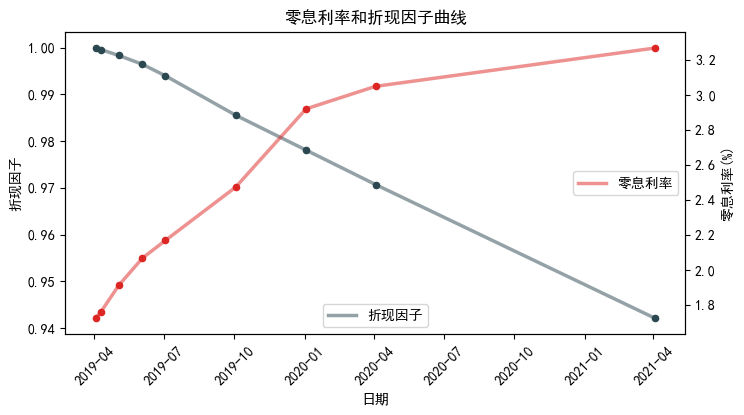

```python
fig, ax1 = plt.subplots(figsize=(8,4), dpi=100)

D, DF, ZR = curve['日期'], curve['折现因子'], curve['零息利率 (%)']

ax1.plot( D, DF, color=dt_hex, linewidth=2.5, alpha=0.5, label='折现因子' )
ax1.scatter( D, DF, 20, color=dt_hex )
ax1.legend(loc=8)
ax1.set_xticklabels( D.dt.strftime('%Y-%m-%d'), rotation=45)
ax1.set_xlabel('日期')
ax1.set_ylabel('折现因子')

ax2 = ax1.twinx()
ax2.plot( D, ZR, color=r_hex, linewidth=2.5, alpha=0.5, label='零息利率' )
ax2.scatter( D, ZR, 20, color=r_hex )
ax2.legend(loc=7)
ax2.set_ylabel('零息利率(%)')

plt.title('零息利率和折现因子曲线')

plt.show()
```

上图用了双 y 轴来区分折现因子和零息利率，左边是折现因子，右边是零息利率，其实通过观察 y 轴的数值也可以区分出来两者。

现在来计算一个三个月的远期利率，它的

- **起息日**是 **2019-08-05**
- **终止日**是 **2019-11-05**

计算远期利率的公式如下：

其中

- $T_s$ =起始日到估值日之间的年限 (使用 **act/365** 日期计数惯例)
- $T_e$ =终止日到估值日之间的年限
- $\tau$ =起始日和终止日之间的年限 (不同货币的日期计数惯例不一样，通常使用 **act/360** )
- $DF(0,T_s)$ = 在 $T_s$ 时点上的折现因子
- $DF(0,T_e)$ = 在 $T_e$ 时点上的折现因子

- 计算曲线上**标准日期**到估值日之间的天数差
- 计算起始日和终止日到估值日之间的天数差，并计算远期利率年限
- 插出起始日和终止日上的折现因子
- 将折现因子带入公式计算远期利率

**第一步**：计算曲线上**标准日期**到估值日之间的天数差

```python
from datetime import datetime
today = datetime.strptime('2019-04-01','%Y-%m-%d')
daydiff = curve['日期'] - today
ddf = daydiff.dt.days.values
ddf
```

```
array([  2,   9,  32,  63,  93, 185, 277, 368, 733], dtype=int64)
```

**第二步**：计算起始日和终止日到估值日之间的天数差，以及远期利率年限

```python
start = datetime.strptime('2019-08-05','%Y-%m-%d')
end = datetime.strptime('2019-11-05','%Y-%m-%d')
d_s = (start - today).days
d_e = (end- today).days
tau = (d_e - d_s)/360
print( d_s, d_e, tau )
```

```
126 218 0.25555555555555554
```

**第三步**：插出起始日和终止日上的折现因子，有多种方法，不同数据商对不同曲线也有不同的设置，常见的四种有：

1. 在折现因子上线性插值
2. 在折现因子上三次样条插值
3. 在 ln(折现因子) 上线性插值
4. 在零息曲线上线性插值，再计算折现因子

### 在折现因子上线性插值

```python
tck = spi.splrep( ddf, curve['折现因子'], k=1 )
DF_s1 = spi.splev( d_s, tck )
DF_e1 = spi.splev( d_e, tck )
F1 = tau*(DF_s1/DF_e1 - 1) * 100
print( DF_s1, DF_e1, F1 )
```

```
0.9909485166188177 0.9828538249018102 0.21047315342110928
```

### 在折现因子上一元三次条插值

```python
tck = spi.splrep( ddf, curve['折现因子'], k=3 )
DF_s2 = spi.splev( d_s, tck )
DF_e2 = spi.splev( d_e, tck )
F2 = tau*(DF_s2/DF_e2 - 1) * 100
print( DF_s2, DF_e2, F2 )
```

```
0.9909572012597055 0.9827493083500931 0.2134392377215762
```

### 在折现因子对数上线性插值

```python
tck = spi.splrep( ddf, np.log(curve['折现因子']), k=1 )
DF_s3 = np.exp(spi.splev( d_s, tck ))
DF_e3 = np.exp(spi.splev( d_e, tck ))
F3 = tau*(DF_s3/DF_e3 - 1) * 100
print( DF_s3, DF_e3, F3 )
```

```
0.9909402218834239 0.9828472942639631 0.21042868265828224
```

### 在零息利率上线性插值

```python
tck = spi.splrep( ddf, curve['零息利率 (%)'], k=1 )
r_s = spi.splev( d_s, tck )
r_e = spi.splev( d_e, tck )
DF_s4 = np.exp(-d_s/365 * r_s/100)
DF_e4 = np.exp(-d_e/365 * r_e/100)
F4 = tau*(DF_s4/DF_e4 - 1) * 100
print( DF_s4, DF_e4, F4 )
```

```
0.9921606726777862 0.9843810241053533 0.20196777104292177
```

比对四种方法计算出来的远期利率：

```python
mtd = ['线性插折现因子','一元三次插折现因子','线性插对数折现因子','线性插零息利率']
var = ['起始日上的折现因子','终止日上的折现因子','远期利率']
data = np.array([[DF_s1, DF_s2, DF_s3, DF_s4],
                 [DF_e1, DF_e2, DF_e3, DF_e4],
                 [F1, F2, F3, F4]]).T
df = pd.DataFrame( data, index=mtd, columns=var )
df
```

|  | 起始日上的折现因子 | 终止日上的折现因子 | 远期利率 |
| --- | --- | --- | --- |
| 线性插折现因子 | 0.990949 | 0.982854 | 0.210473 |
| 一元三次插折现因子 | 0.990957 | 0.982749 | 0.213439 |
| 线性插对数折现因子 | 0.990940 | 0.982847 | 0.210429 |
| 线性插零息利率 | 0.992161 | 0.984381 | 0.201968 |

```python
def highlight_max(df):
    is_max = (df == df.max())
    return ['color: red' if v else '' for v in is_max]

def highlight_min(df):
    is_min = (df == df.min())
    return ['color: blue' if v else '' for v in is_min]

num_fmt = "{0:,.4f}"
pct_fmt = "{0:,.4f}%"
df_fmt = {var[0]:num_fmt, var[1]:num_fmt, var[2]:pct_fmt}

df.style.apply(highlight_max).apply(highlight_min).format(df_fmt)
```

|  | 起始日上的折现因子 | 终止日上的折现因子 | 远期利率 |
| --- | --- | --- | --- |
| 线性插折现因子 | 0.9909 | 0.9829 | 0.2105% |
| 一元三次插折现因子 | 0.9910 | 0.9827 | 0.2134% |
| 线性插对数折现因子 | 0.9909 | 0.9828 | 0.2104% |
| 线性插零息利率 | 0.9922 | 0.9844 | 0.2020% |

# 3. 数值积分

回到目录

在 scipy 中有个专门的函数 `scipy.integrate` 是用来计算数值积分的，首先引进它并记为 `sci`。

```python
import scipy.integrate as sci
```

### 3.1 简单例子

回到章首

对函数 $\sin(x) + 0.5x$ 数值求积分，首先定义被积函数 $f(x)$：

```python
f = lambda x: np.sin(x) + 0.5 * x
```

假设在 $[0.5, 9.5]$ 对 $f(x)$ 求积分，其解析表达式为：

$$ \int_{0.5}^{9.5} (\sin(x)+0.5x)dx = [-\cos(x)+0.25x^2]\Big|_{0.5}^{9.5} = 24.37475471808675$$

用下面代码确认上面的结果

```python
(-np.cos(9.5) + 0.25 * 9.5**2) - (-np.cos(0.5) + 0.25 * 0.5**2)
```

```
24.37475471808675
```

对函数 $f(x)$ 在 $[a, b]$ 上求积分：其几何含义是在区间 $[a, b]$ 上 $f(x)$ 在 x 轴上方与 x 轴围成的面积减去 $f(x)$ 在 x 轴下方与 x 轴围成的面积。

```python
a, b = 0.5, 9.5
x = np.linspace(0, 10, 100)
y = f(x)
```

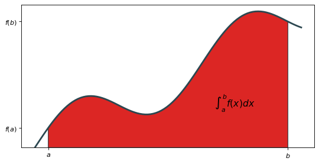

```python
from matplotlib.patches import Polygon

fig, ax = plt.subplots(figsize=(8,4), dpi=80)
plt.plot( x, y, color=dt_hex, linewidth=2.5 )
plt.ylim(ymin=0)

Ix = np.linspace(a, b)
Iy = f(Ix)
verts = [(a, 0)] + list(zip(Ix, Iy)) + [(b, 0)]
poly = Polygon( verts, facecolor=r_hex, edgecolor=dt_hex )
ax.add_patch( poly )

plt.text( 0.75*(a + b), 1.5, r"$\int_a^b f(x)dx$", horizontalalignment='center', fontsize=14 )
ax.set_xticks( (a, b) )
ax.set_xticklabels( ('$a$', '$b$') )
ax.set_yticks ([f(a), f(b)] )
ax.set_yticklabels( ('$f(a)$', '$f(b)$') )
plt.show()
```

在 `scipy.integrate` 里有五个数值积分的函数：

- `fixed_quad`：fixed Gaussian quadrature (定点高斯积分)
- `quad`：adaptive quadrature (自适应积分)
- `romberg`：Romberg integration (龙贝格积分)
- `trapz`：用 trapezoidal 法则
- `simps`：用 Simpson’s 法则

前三个函数 `fixed_quad`, `quad`, `romberg` 有三个参数，分别是**被积函数**、**下界**和**上界**，使用它们的代码范式为

```
func( f, lb, ub )
```

```python
sci.fixed_quad(f, a, b)[0]
```

```
24.366995967084602
```

```python
sci.quad(f, a, b)[0]
```

```
24.374754718086752
```

```python
sci.romberg(f, a, b)
```

```
24.374754718086713
```

对后两个函数 `trapz` 和 `simps`，首先在上下界之间取 $n$ 个点 $x_i$，再求出对应的函数值 $f(x_i)$，再把当参数 $f(x_i)$ 和 $x_i$ 传到函数中。代码如下：

```python
xi = np.linspace(a, b, 100)
```

```python
sci.trapz( f(xi), xi )
```

```
24.373463386819818
```

```python
sci.simps( f(xi), xi )
```

```
24.37474011548407
```

解析解求得的积分值 24.37475471808675 比较，`quad` 的结果最精确。当被积函数不规则时 (某段函数值激增)，`quad` 这种自适应积分通常的结果很好。

### 3.2 金融案例

回到章首

数据积分是量化金融中非常重要，尤其是在衍生品定价领域。因为衍生品的价值在风险中性测度下通常表示其收益的折现期望，而期望又可以表示为收益函数的积分。

下面在布莱尔斯科尔斯 (Black-Scholes, BS) 模型下用数值积分定价欧式期权，但其实欧式期权有解析解，我们先计算解析解，在比对数值解。

### 解析解

在 **BS** 模型下，原生资产 (以股票价格为例) 的随机微分方程如下：

\begin{equation} \frac{dS(t)}{S(t)} = (r-q)dt+\sigma dW(t) \end{equation}

其中

- $S(t)$ = 资产在时点 $t$ 的值
- $r$ = 常数型瞬时利率
- $q$ = 常数型瞬时红利率
- $\sigma$ = 常数型瞬时波动率
- $W(t)$ = 布朗运动

根据 **BS** 公式，欧式期权的解析解为

\begin{equation} \begin{aligned} V = e^{-rT} \cdot E\left[ \left[ \omega\left(S_T-K\right)\right]^+\right] = \omega\cdot\left[e^{-qT}S_0\Phi(\omega\cdot d_+) - e^{-rT}K\Phi(\omega\cdot d_{-})\right] \end{aligned} \end{equation}

其中

\begin{equation} d_{\pm} = \frac{1}{\sigma\sqrt{T}}\ln\left(\frac{S_0e^{(r-q)T}}{K}\right)\pm\frac{\sigma\sqrt{T}}{2} \end{equation}

看涨期权对应 $\omega = 1$，看跌期权对应 $\omega = -1$。

```python
def blackscholes( S0=100, K=100, r=0.01, q=0.01, T=1, sigma=0.2, omega=1 ):
    discount = np.exp(-r*T)
    forward = S0*np.exp((r-q)*T)
    moneyness = np.log(forward/K)
    vol_sqrt_T = sigma*np.sqrt(T)

    d1 = moneyness / vol_sqrt_T + 0.5*vol_sqrt_T
    d2 = d1 - vol_sqrt_T

    V = omega * discount * (forward*norm.cdf(omega*d1) - K*norm.cdf(omega*d2))
    return V
```

```python
(S0, K, r, q, T, sigma, omega) = (100, 95, 0.01, 0, 1, 0.1, 1)
blackscholes(S0, K, r, q, T, sigma, omega)
```

```
7.545870893948695
```

### 数值解

将收益函数的期望转成积分形式，得到

\begin{equation} \begin{aligned} \text{call} &= e^{-rT} \cdot E\left[ \left( S_T-K\right)^+\right] \\ &= e^{-rT} \cdot \int_{K}^{+\infty} \left( S_T-K\right)\cdot f_S(S_T)dS_T \\ &\stackrel{x=lnS_T}= e^{-rT} \cdot \int_{\ln K}^{+\infty} \left( e^x-K\right)\cdot f_X(x)dx \end{aligned} \end{equation}

首先用伊藤公式 (Ito's lemma) 推出 $\ln S$ 的随机微分方程：

\begin{equation} \begin{aligned} d\ln S &= df(S) \\ &= f_SdS + \frac{f_{SS}}{2}dS^2 \\ &= \frac{1}{S}dS - \frac{1}{2S^2}dS^2 \\ &= \frac{1}{S}(r-q)Sdt + \sigma SdW(t) - \frac{1}{2S^2}\sigma^2S^2dt \\ &= \left(r-q-\frac{1}{2}\sigma^2\right) + \sigma dW(t) \end{aligned} \end{equation}

从 $0$ 到 $T$ 两边求积分，整理得到 $S_T$ 的解。

\begin{equation} S_T = S_0 \cdot \exp{\left(\int_0^T\left(r-q-\frac{1}{2}\sigma^2\right)dt + \int_0^T\sigma dW(t)\right)} = S_0 \cdot \exp{\left(\left(r-q-\frac{1}{2}\sigma^2\right)T + \sigma \sqrt{T}\cdot z\right)} \end{equation}

其中 $z$ 是标准正态分布变量 $z \sim \mathcal{N}(0,1)$。

用之前的变量转化 $x = \ln S_T$ 得到 $x$ 的解。

\begin{equation} x = \ln S_T = \ln S_0 + \left(\left(r-q-\frac{1}{2}\sigma^2\right)T+\sigma\sqrt{T}z\right) \sim N\left(\ln S_0 +\left(r-q-\frac{1}{2}\sigma^2\right)T,\sigma^2T\right) \end{equation}

将 $x$ 的表达式带入上式得到：

\begin{equation} \text{call} = e^{-rT} \cdot \int_{\ln K}^{+\infty} \left( e^x-K\right)\cdot \phi\left(x, \ln S_0 +\left(r-q-\frac{1}{2}\sigma^2\right)T,\sigma^2T\right)dx \end{equation}

其中 $\phi(\cdot)$ 是标准正态随机变量的概率密度函数 (Probability Density Function, PDF)。

用 **`lambda`** 匿名函数来表示被积函数，定义上界和下界：

```python
mu = np.log(S0) + ((r-q)*T-0.5*sigma**2*T)
v = sigma*np.sqrt(T)

f = lambda x: np.exp(-r*T) * (np.exp(x)-K) * norm.pdf(x,mu,v)

(lb, ub) = (np.log(K), 7)
```

注意上界不要定义成 $\inf$。稍微分析下 $x = \ln S_T$，当 $S_T= e^7 ≈ 1097$ 对于 $S_0 = 100$ 已经很大了，因此上界设为 7 比较合理。

用之前介绍的五种积分函数计算期权价值：

```python
sci.fixed_quad(f, lb, ub)[0]
```

```
11.144780900890668
```

```python
sci.quad(f, lb, ub)[0]
```

```
7.5458708939487416
```

```python
sci.romberg(f, lb, ub)
```

```
4.0285595322300014e-27
```

```python
xi = np.linspace(lb, ub, 1000)
sci.trapz( f(xi), xi )
```

```
7.545710890002891
```

```python
sci.simps( f(xi), xi )
```

```
7.545873261737196
```

发现 `quad`, `trapz` 和 `simps` 的结果和解析解 7.545870893948695 都相当接近，而 `fixed_quad` 和 `romberg` 差的很远。

用数值积分来求解欧式期权的确有点多此一举 (ovekill)，但很多复杂的产品是没有解析解的，除了用数值解的**偏微分方法有限差分方法**和**蒙特卡洛方法**，数值积分也是一种选择。

# 4. 统筹规划

回到目录

在 scipy 中有个专门的函数 `scipy.optimize` 是用来做优化的，首先引进它并记为 `spo`。

```python
import scipy.optimize as spo
```

优化问题可分为**无约束优化** (unconstrained optimization) 和**有约束优化** (constrained optimization)，我们用简单例子来介绍前者，用金融例子来介绍后者。

### 4.1 简单例子

回到章首

首先定义函数 $f(x,y) = \sin(x) +0.05x^2 + \sin(y) +0.05y^2$

```python
f = lambda x,y: np.sin(x) + 0.05 * x**2 + np.sin(y) + 0.05 * y**2
```

```python
x = np.linspace(-10, 10, 50)
y = np.linspace(-10, 10, 50)
X, Y = np.meshgrid(x, y)
Z = f(X, Y)
```

接着可视化函数 $Z$。

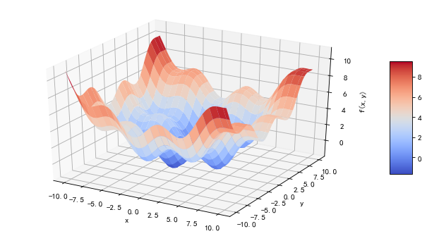

```python
from mpl_toolkits.mplot3d import Axes3D

fig = plt.figure(figsize=(8, 4), dpi=80)
ax = Axes3D(fig)

surf = ax.plot_surface( X, Y, Z, rstride=2, cstride=2, cmap=plt.cm.coolwarm, linewidth=0.5 )
ax.set_xlabel('x')
ax.set_ylabel('y')
ax.set_zlabel('f(x,y)')
fig.colorbar( surf, shrink=0.5, aspect=5 )

plt.show()
```

从上图来看 $Z$ 有几个局部最小值 (local minimum)，但是很难判断 $Z$ 是否有唯一的全局最小值 (global minimum)。 我们目标是求后者，主要步骤如下：

- 在 $(x, y)$ 定义域上选点，求出函数值 $f(x,y)$，找出最小值对应的 $x^*$ 和 $y^*$
- 用 $(x^*, y^*)$ 当初始值，求出函数全局最小值

**第一步**：用**蛮力法**找函数最小值以及对应的参数

之所以用**蛮力**一词，是因为接下来要用到 `brute` 函数，而 bruteforce 就是蛮力的意思。

首先定义函数 `fo` (其实等价于上面的 `f` 函数)，只不过 `brute` 函数要求的参数格式是**一个元组**，而不是若干个参数。此外我们添加一个 `print()` 语句，为了检查中间产出。

```python
def fo(xy):
    x, y = xy
    z = np.sin(x) + 0.05 * x ** 2 + np.sin(y) + 0.05 * y ** 2
    if output == True:
        print( f'x = {x:8.4f}, y = {y:8.4f}, z = {x:8.4f}' )
    return z
```

将 $x$ 和 $y$ 从 -10 到 10 以步长为 5 来切片 (切片是前闭后开的，因此切片完得到的是 -10, -5, 0, 5，而不包括 10 这个点)

在下面使用的 `brute` 函数中，最后 `finish` 参数可以设置为：

- `None`： 在给定网格中的点中求出最小值。
- `optimize.fmin` : 直接求出函数最小值。但是这种方式对于复杂函数求极值非常低效。

因此我们还是希望先给定一个**稀疏**网格，求出最小值对应的 $(x,y)$ 作为进一步优化的初始值。

```python
output = True
xy = ((-10, 10, 5), (-10, 10, 5))
opt1 = spo.brute(fo, xy, finish=None)
opt1
```

```
x = -10.0000, y = -10.0000, z = -10.0000
x = -10.0000, y =  -5.0000, z = -10.0000
x = -10.0000, y =   0.0000, z = -10.0000
x = -10.0000, y =   5.0000, z = -10.0000
x =  -5.0000, y = -10.0000, z =  -5.0000
x =  -5.0000, y =  -5.0000, z =  -5.0000
x =  -5.0000, y =   0.0000, z =  -5.0000
x =  -5.0000, y =   5.0000, z =  -5.0000
x =   0.0000, y = -10.0000, z =   0.0000
x =   0.0000, y =  -5.0000, z =   0.0000
x =   0.0000, y =   0.0000, z =   0.0000
x =   0.0000, y =   5.0000, z =   0.0000
x =   5.0000, y = -10.0000, z =   5.0000
x =   5.0000, y =  -5.0000, z =   5.0000
x =   5.0000, y =   0.0000, z =   5.0000
x =   5.0000, y =   5.0000, z =   5.0000
```

```
array([0., 0.])
```

```python
fo(opt1)
```

[output not shown]

```
0.0
```

从上面结果可看出，函数在 $(0, 0)$ 是取最小值 $0$。是否是最小值吗还不知道，但以 5 为步长太大了，接下来试试以 0.1 为步长。(这时把 output 设为 False 避免打印太多行内容)。

```python
output = False
xy = ((-10, 10, 0.1), (-10, 10, 0.1))
opt1 = spo.brute(fo, xy, finish=None)
opt1
```

```
array([-1.4, -1.4])
```

```python
fo(opt1)
```

```
-1.7748994599769203
```

当步长变小，我们能在更细的网格上计算函数值，这是函数在 (-1.4, -1.4) 取最小值 -1.7749，明显比函数在 (0, 0) 上的值 0 要小。

**第二步**：把 (-1.4, -1.4) 当初始值，求函数全局最小值

如果网格足够密，上面 -1.7749 大概率是全局最小值而 (-1.4, -1.4) 是对应的最优解；如果网格不是足够密，那么以 (-1.4, -1.4) 当初始值，也能很大概率找到全局最小值。

用 `fmin` 函数，将刚才 `opt1` 传进去，并设定四个终止条件

- `xtol`: 每次迭代自变量值的绝对差异的绝对值的容忍度。
- `ftol`：每次迭代函数值的绝对差异的绝对值的容忍度。
- `maxiter`: 最多迭代次数 。
- `maxfun`: 函数运行的最多次数。

```python
output = True
opt2 = spo.fmin( fo, opt1, xtol=0.001, ftol=0.001, maxiter=15, maxfun=20 )
opt2
```

```
x =  -1.4000, y =  -1.4000, z =  -1.4000
x =  -1.4700, y =  -1.4000, z =  -1.4700
x =  -1.4000, y =  -1.4700, z =  -1.4000
x =  -1.3300, y =  -1.4700, z =  -1.3300
x =  -1.4350, y =  -1.4175, z =  -1.4350
x =  -1.4350, y =  -1.3475, z =  -1.4350
x =  -1.4088, y =  -1.4394, z =  -1.4088
x =  -1.4438, y =  -1.4569, z =  -1.4438
x =  -1.4328, y =  -1.4427, z =  -1.4328
x =  -1.4591, y =  -1.4208, z =  -1.4591
x =  -1.4213, y =  -1.4347, z =  -1.4213
x =  -1.4235, y =  -1.4096, z =  -1.4235
x =  -1.4305, y =  -1.4344, z =  -1.4305
x =  -1.4168, y =  -1.4516, z =  -1.4168
x =  -1.4305, y =  -1.4260, z =  -1.4305
x =  -1.4396, y =  -1.4257, z =  -1.4396
x =  -1.4259, y =  -1.4325, z =  -1.4259
x =  -1.4259, y =  -1.4241, z =  -1.4259
x =  -1.4304, y =  -1.4177, z =  -1.4304
x =  -1.4270, y =  -1.4288, z =  -1.4270
Warning: Maximum number of function evaluations has been exceeded.
```

```
array([-1.42702972, -1.42876755])
```

```python
fo(opt2)
```

```
x =  -1.4270, y =  -1.4288, z =  -1.4270
```

```
-1.7757246992239009
```

此时最优解为 (-1.42702972, -1.42876755)，而对应的函数值为 -1.7757246992239009 比 (-1.4, 1.4) 对应的函数值 -1.7748994599769203 又要小点。

好的初始值对求函数的最优解影响比较大。假设我们无脑用 (2, 2) 当初始值，看看会发生什么。

```python
output = False
opt3 = spo.fmin(fo, (2, 2), maxiter=250)
opt3
```

```
Optimization terminated successfully.
         Current function value: 0.015826
         Iterations: 46
         Function evaluations: 86
```

```
array([4.2710728 , 4.27106945])
```

```python
fo(opt3)
```

```
0.0158257532746805
```

求得函数在 (4.2710728, 4.2710728) 取的最小值 0.015826，差的太远了。

### 4.2 金融案例

回到章首

优化在金融和经济学中起着重要作用。例如，根据市场数据做模型校正 (model calibration)，或最大化效用 (utility)。 在上节中，我们考虑了无约束的优化问题。在实际的金融优化问题通常受到一个或多个约束，并且约束可以是等式或不平式。

考虑一个投资者的效用最大化问题，该投资者可以投资 2 个资产 A 和 B。

- 两种资产现值格均为 10 美元。
- 一年后，有两种等概率发生的情景，A 和 B也有相应的两种回报：
  - 情景一：A 支付 15 美元，B 支付 5 美元
  - 情景二：A 支付 5 美元，B 支付 12 美元
- 投资者的初始预算为 $w_0$ = 100 美元
- 效用函数为 $U(w) = \sqrt{w}$

很多软件只编写了最小化问题的算法，因此我们可将**最大化效用**转成**最小化负效用**。下面是最小化问题的表述，其中 $a$ 和 $b$ 是投资者投资的资产 A 和 B 的数量。

\begin{equation*} \begin{aligned} & \underset{a,b}{\text{minimize}} & & -(0.5\cdot\sqrt{15a+5b} + 0.5\cdot\sqrt{5a+12b}) \\ & \text{subject to} & & 10a + 10b \leq 100, a \geq 0, b \geq 0 \end{aligned} \end{equation*}

要解决上面的最小化问题，我们使用 `scipy.optimize.minimize`， 需要设定好

- `obj`：目标函数，简单的话用 **`lambda` 匿名函数**，复杂的话用 **`def` 普通函数**。
- `cons`：限制条件有两种形式，等式 (eq) 和不等式 (ineq)，分别用**字典**的形式表达，而限制条件的表达式用**匿名函数**来表示。
- `bnds`：自变量的上下界，用**元组**来表示。

```python
# 目标函数
obj = lambda x: -(0.5 * np.sqrt(x[0]*15 + x[1]*5) + 0.5 * np.sqrt(x[0]*5 + x[1]*12))

# 不等式约束条件
cons = [ {'type': 'ineq', 'fun': lambda x: 100 - x[0]*10 - x[1]*10} ]

# 上下界
bnds = ( (0, 1000), (0, 1000) )

result = spo.minimize( obj, [5, 5], method='SLSQP', bounds=bnds, constraints=cons )
result
```

```
     fun: -9.700883611487832
     jac: array([-0.48508096, -0.48489535])
 message: 'Optimization terminated successfully.'
    nfev: 21
     nit: 5
    njev: 5
  status: 0
 success: True
       x: array([8.02547122, 1.97452878])
```

`result` 是一个字典，我们可以用键 `x` 和 `fun` 查看最优参数和函数最小值。

```python
result['x']
```

```
array([8.02547122, 1.97452878])
```

```python
result['fun']
```

```
-9.700883611487832
```

# 5. 有限差分

回到目录

在 scipy 中有个专门的函数 `scipy.sparse` 是用在有限差分中稀疏矩阵，首先引进它并记为 `sp`。 此外引进 `linalg` 做线性代数相关的操作。

```python
import scipy.sparse as sp
import scipy.linalg as sla
```

### 5.1 简单例子

回到章首

## 稀疏矩阵

- COO (Coordinate List Format)：**座标格式**，非零值按着**行坐标**和**纵坐标**写成两个列表，容易创建但是不便于矩阵计算，用 `coo_matrix`
- LIL (List of List): 支持切片但也不便于矩阵计算，用 `lil_matrix`
- CSR (Compressed Sparse Row)： **压缩行格式**，不容易创建但便于矩阵计算，用 `csr_matrix`
- CSC (Compressed Sparse Column)： **压缩列格式**，不容易创建但便于矩阵计算，用 `csc_matrix`
- DIA (Diagnoal)：**对角线格式**，适合矩阵计算，用 `dia_matrix`

### `coo_matrix`

```python
values = [1, 2, 3, 4]
rows = [0, 1, 2, 3]
cols = [1, 3, 2, 0]
A = sp.coo_matrix((values, (rows, cols)), shape=[4, 4])
A
```

```
<4x4 sparse matrix of type '<class 'numpy.int32'>'
	with 4 stored elements in COOrdinate format>
```

```python
A.shape, A.size, A.dtype, A.ndim, A.nnz, A.data
```

```
((4, 4), 4, dtype('int32'), 2, 4, array([1, 2, 3, 4]))
```

```python
A.row, A.col
```

```
(array([0, 1, 2, 3], dtype=int32), array([1, 3, 2, 0], dtype=int32))
```

如果想看 `A` 中的元素，我们可用 `toarray()` 转换成 `numpy` 数组显示出来。

```python
A.toarray()
```

```
array([[0, 1, 0, 0],
       [0, 0, 0, 2],
       [0, 0, 3, 0],
       [4, 0, 0, 0]])
```

COO 矩阵的元素无法进行增删改操作，一般创建成功之后可以转化成其他格式的稀疏矩阵 (如 CSR, CSC) 进行转置、矩阵乘法等操作，或者转成转成 LIL 做切片。

```python
A.tocsr()
```

```
<4x4 sparse matrix of type '<class 'numpy.int32'>'
	with 4 stored elements in Compressed Sparse Row format>
```

```python
A.tolil()
```

```
<4x4 sparse matrix of type '<class 'numpy.int32'>'
	with 4 stored elements in List of Lists format>
```

### `dia_matrix`

```python
data = np.arange(1,13).reshape(3,-1)
offset = [-1, 0, 1]
A = sp.dia_matrix( (data, offset), shape=(4,4) )
A.toarray()
```

```
array([[ 5, 10,  0,  0],
       [ 1,  6, 11,  0],
       [ 0,  2,  7, 12],
       [ 0,  0,  3,  8]])
```

在 `sp.sparse` 模块里还有一些直接创建稀疏矩阵的函数：

- `eye` 生成稀疏单位对角阵
- `diags` 构建稀疏对角阵
- `spdiags` 构建稀疏对角阵

```python
N = 5
A = sp.eye(N, k=1) - 2 * sp.eye(N) + sp.eye(N, k=-1)
A.toarray()
```

```
array([[-2.,  1.,  0.,  0.,  0.],
       [ 1., -2.,  1.,  0.,  0.],
       [ 0.,  1., -2.,  1.,  0.],
       [ 0.,  0.,  1., -2.,  1.],
       [ 0.,  0.,  0.,  1., -2.]])
```

```python
A = sp.diags([1, -2, 1], [1, 0, -1], (N, N), format='csc')
A.toarray()
```

```
array([[-2.,  1.,  0.,  0.,  0.],
       [ 1., -2.,  1.,  0.,  0.],
       [ 0.,  1., -2.,  1.,  0.],
       [ 0.,  0.,  1., -2.,  1.],
       [ 0.,  0.,  0.,  1., -2.]])
```

```python
data = np.vstack( [np.repeat(1,N), np.repeat(-2,N), np.repeat(1,N)] )
A = sp.spdiags( data, [1, 0, -1], N, N )
A.toarray()
```

```
array([[-2,  1,  0,  0,  0],
       [ 1, -2,  1,  0,  0],
       [ 0,  1, -2,  1,  0],
       [ 0,  0,  1, -2,  1],
       [ 0,  0,  0,  1, -2]])
```

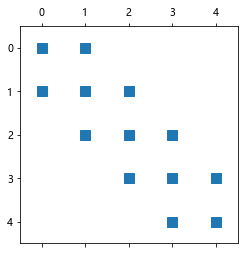

```python
fig, ax = plt.subplots()
ax.spy(A)
plt.show()
```

### 5.2 金融案例

回到章首

考虑一个看跌期权，它的特征如下表所示：

| 属性 | 符号 | 值 |
| --- | --- | --- |
| 股票价格 | $S$ | 50 |
| 行权价格 | $K$ | 60 |
| 连续利率 | $r$ | 3% |
| 连续红利率 | $q$ | 1% |
| 波动率 | $\sigma$ | 40% |
| 到期年限 | $T$ | 1 |

用偏微分方程有限差分对期权定价分五步：

- 方程解域 (solution domain)
- 网格打点 (grid construction)
- 终边条件 (terminal and boundary condition)
- 时空离散 (spatial and time discretization)
- 差分格式 (finite difference scheme)

### 确定方程解域

给定偏微分方程，第一件事就是定下它的解域，因为你不可能求出它在无限域的解。金融产品一般都会有个有限的到期日 $T$，而股票价格 $S$ 值也应该有个范围。在本例中期权 1 年后到期因此将 T 设为 1。股价通常是整数，因此将 $S_{\min}$ 设为 0，通常 $S_{\max}$ 设为股票价格和行权价格最大值的 4 倍，即 $4×\max(50, 60)$ 为 240。

这样解域就确定下来了，$t ∊ [0, 1]$ 和 $S ∊ [0, 240]$。

```python
(S, K, r, q, T, sigma, option_type) = (50, 60, 0.03, 0.01, 1, 0.4, 'put')
(Smin, Smax, Ns, Nt) = (0, 4*np.maximum(S,K), 4, 4)
```

```python
import matplotlib.ticker as ticker
```

```python
def plot_solution_domain():
    fig = plt.figure(figsize=(4,4), dpi=100)
    ax = fig.add_subplot(1,1,1)

    points = np.array([0, 1])
    xs, ys = np.meshgrid(points, points)

    ax.scatter(xs, ys, color='k')
    ax.plot( np.array([0,0]), np.array([0,1]), color='k', alpha=0.2)
    ax.plot( np.array([1,1]), np.array([0,1]), color='k', alpha=0.2)
    ax.plot( np.array([0,1]), np.array([0,0]), color='k', alpha=0.2)
    ax.plot( np.array([0,1]), np.array([1,1]), color='k', alpha=0.2)

    ax.xaxis.set_major_locator(ticker.NullLocator())
    ax.yaxis.set_major_locator(ticker.NullLocator())

    for spine in ax.spines.values():
         spine.set_visible(False)

    # 设定标题和纵轴的标注
    ax.text( -0.1, 0, '$0$', ha='center')
    ax.text( -0.1, 1, '$240$', ha='center')
    ax.text( 0, 1.05, '$0$', ha='center')
    ax.text( 1, 1.05, '$1$', ha='center')

    ax.set_title('t', size=15, alpha=0.5)
    ax.set_ylabel('S', size=15, alpha=0.5)
```

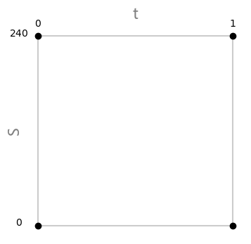

```python
plot_solution_domain()
```

### 建立网格

上图解域中有无限个点，偏微分方程在任何一个点上都成立，但在所有点上求出方程显然不现实，实操上只需在有限个点求解方程，而这些点组成了网格。网格分为等距网格 (equidistant grids) 和不等距网格 (non-equidistant grids)，为了简化，这里只考虑等距网格，在 $S$-轴和 $t$-轴上等分成 4 份，即每个轴上有五个点。

具体写出网格点写成 $(t_i, S_j)$ 形式，总共有 25 个，在 $S$-轴第 3 个和 $t$-轴第 2 个点的坐标为 $(t_1, S_2)$，因此下标是从零开始计数的。

```python
def plot_grid( S_arr, t_arr ):
    fig = plt.figure(figsize=(6,6), dpi=200)
    ax = fig.add_subplot(1,1,1)

    t_mat, S_mat = np.meshgrid(t_arr, S_arr)
    ax.scatter(t_mat, S_mat, facecolor='grey', s=60, edgecolors=None )

    # 设定标题和纵轴的标注
    ax.set_title('$0$-----------------------$t$--------------------->$T$', size=15, alpha=0.5)
    ax.set_ylabel('$S_{\min}$-----------------$S$-------------------->$S_{\max}$', size=15, alpha=0.5)

    # 去除横轴和纵轴的刻度，去除边框
    ax.xaxis.set_major_locator(ticker.NullLocator())
    ax.yaxis.set_major_locator(ticker.NullLocator())

    for spine in ax.spines.values():
        spine.set_visible(False)

    dS = S_arr[1]-S_arr[0]
    for t, S in zip(t_mat.flatten(), S_mat.flatten()):
        ax.text( t, S-dS/3, f'({t}, {S})', ha='center', size=8 )
```

```python
(Smin, Smax, Tmin, Tmax, Ns, Nt) = (0, np.maximum(S,K), 0, T, 4, 4)
S_arr, t_arr = np.linspace(Smin, Smax, Ns+1), np.linspace(Tmin, Tmax, Nt+1)
```

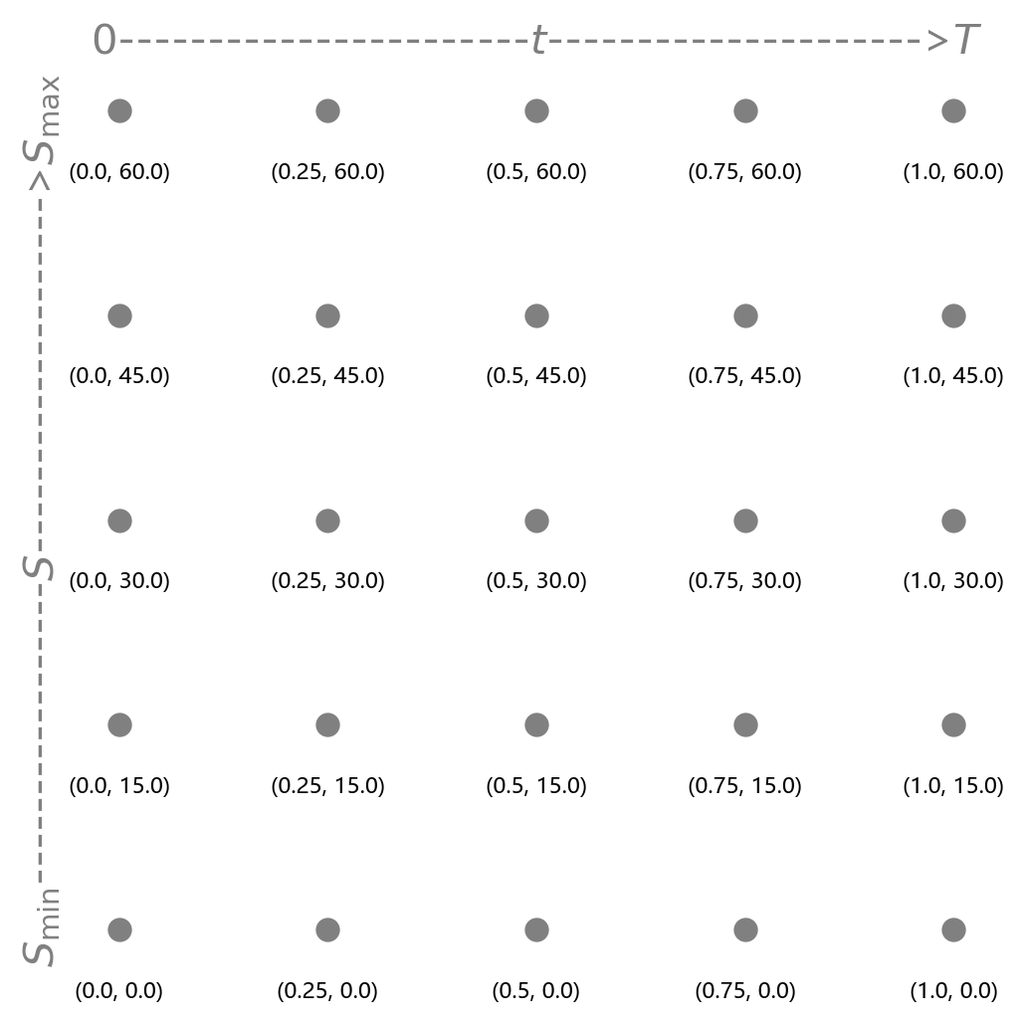

```python
plot_grid( S_arr, t_arr )
```

```python
def plot_grid_withTCBC( S_arr, t_arr ):
    fig = plt.figure(figsize=(6,6), dpi=200)
    ax = fig.add_subplot(1,1,1)

    t_mat, S_mat = np.meshgrid(t_arr, S_arr)
    ax.scatter(t_mat, S_mat, facecolor='grey', s=60, edgecolors=None )

    # 设定标题和纵轴的标注
    ax.set_title('$0$-----------------------$t$--------------------->$T$', size=15, alpha=0.5)
    ax.set_ylabel('$S_{\min}$-----------------$S$-------------------->$S_{\max}$', size=15, alpha=0.5)

    # 去除横轴和纵轴的刻度，去除边框
    ax.xaxis.set_major_locator(ticker.NullLocator())
    ax.yaxis.set_major_locator(ticker.NullLocator())

    for spine in ax.spines.values():
        spine.set_visible(False)

    # 给边界条件和终止条件的点上颜色，并标注
    ax.scatter(t_mat[[0, 1]], S_mat[[0, -1]], facecolor=dt_hex, s=60, edgecolors=None)
    ax.scatter(t_mat[:, -1], S_mat[:, -1], facecolor=r_hex, s=60, edgecolors=None)

    dt = t_arr[1]-t_arr[0]
    dS = S_arr[1]-S_arr[0]
    ax.text(t_arr.mean(), S_arr.min()-S/10, '边界条件', ha='center', color=dt_hex)
    ax.text(t_arr.mean(), S_arr.max()+S/20, '边界条件', ha='center', color=dt_hex)
    ax.text(t_arr.max()+dt/8, S_arr.mean(), '终值条件', rotation='vertical', color=r_hex)

    return ax
```

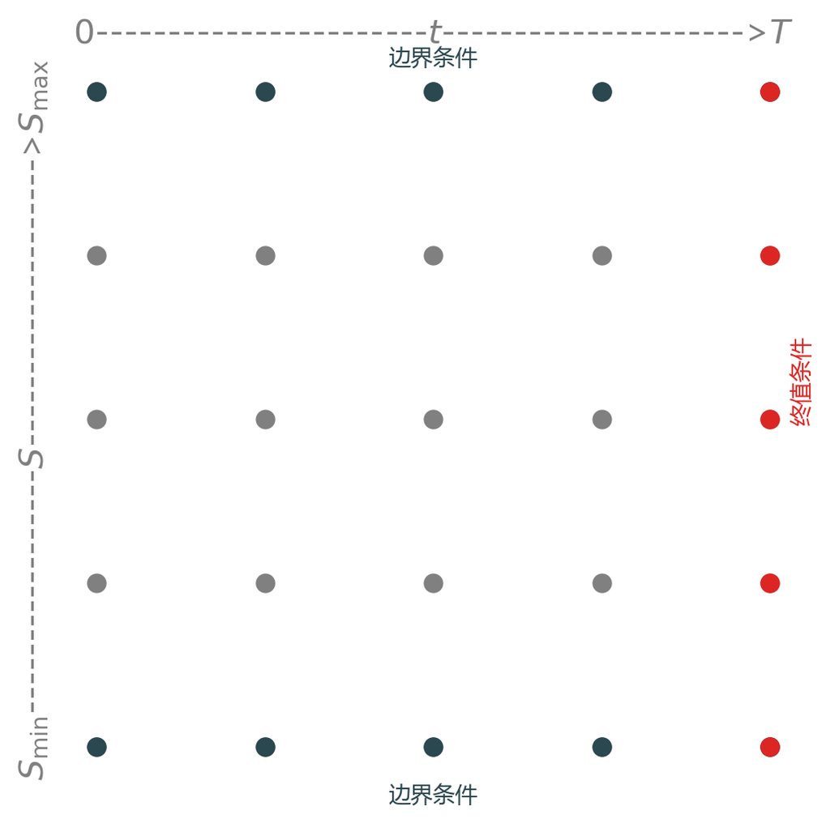

```python
plot_grid_withTCBC( S_arr, t_arr );
```

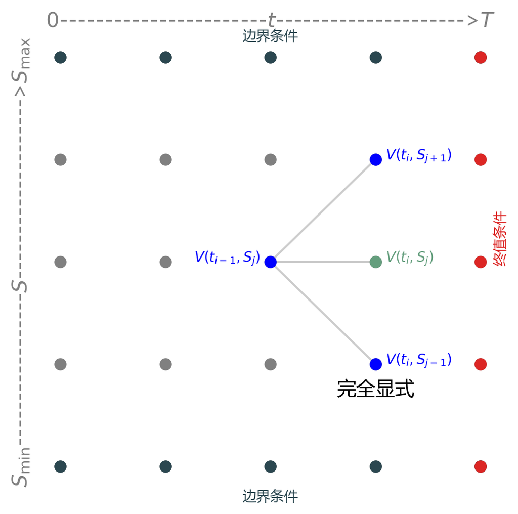

```python
ax = plot_grid_withTCBC( S_arr, t_arr )

size=10
dt = t_arr[1]-t_arr[0]
dS = S_arr[1]-S_arr[0]

(i,j) = (2,2)
(ti,Sj) = (t_arr[i], S_arr[j])
ax.plot( [ti, ti+dt], [Sj, Sj-dS], color='k', alpha=0.2, zorder=0 )
ax.plot( [ti, ti+dt], [Sj, Sj], color='k', alpha=0.2, zorder=0 )
ax.plot( [ti, ti+dt], [Sj, Sj+dS], color='k', alpha=0.2, zorder=0 )

ax.scatter(ti+dt, Sj, facecolor=g_hex, s=60, edgecolors=None, zorder=1 )
ax.scatter(ti+dt, Sj-dS, facecolor='b', s=60, edgecolors=None, zorder=1 )
ax.scatter(ti+dt, Sj+dS, facecolor='b', s=60, edgecolors=None, zorder=1 )
ax.scatter(ti, Sj, facecolor='b', s=60, edgecolors=None, zorder=1 )

ax.text( ti+dt, Sj-1.3*dS, '完全显式', ha='center', size=14 )
ax.text( ti-0.1*dt, Sj, '$V(t_{i-1}, S_j)$', ha='right', color='b', size=size )
ax.text( ti+1.1*dt, Sj-dS, '$V(t_{i}, S_{j-1})$', ha='left', color='b',  size=size )
ax.text( ti+1.1*dt, Sj, '$V(t_{i}, S_{j})}$', ha='left', color=g_hex, size=size )
ax.text( ti+1.1*dt, Sj+dS, '$V(t_{i}, S_{j+1})$', ha='left',  color='b', size=size )

plt.show()
```

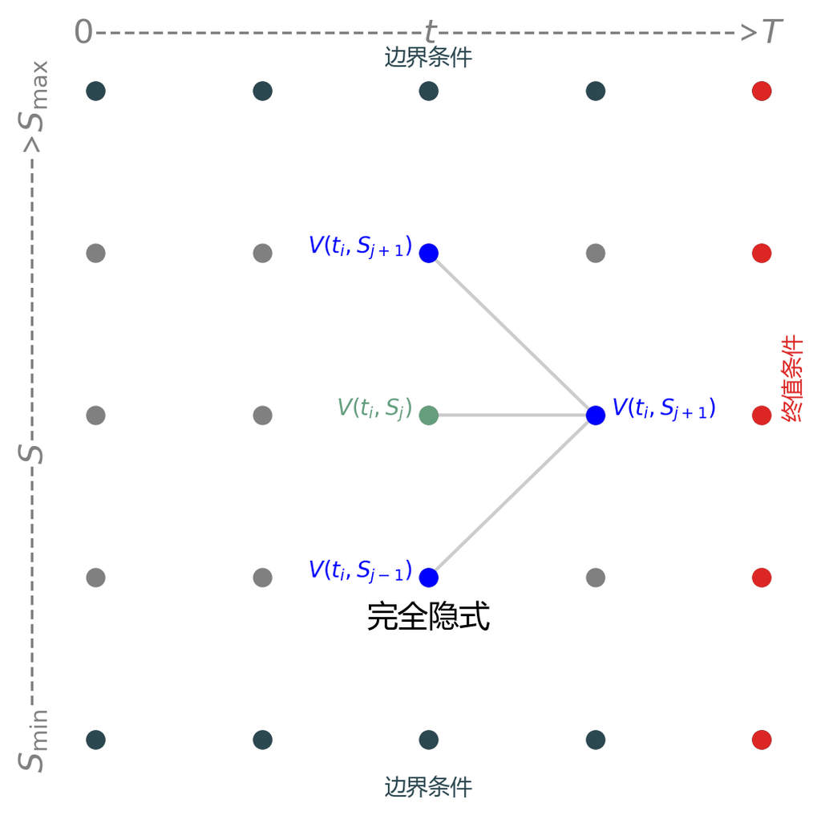

```python
ax = plot_grid_withTCBC( S_arr, t_arr )

size=10
dt = t_arr[1]-t_arr[0]
dS = S_arr[1]-S_arr[0]

(i,j) = (2,2)
(ti,Sj) = (t_arr[i], S_arr[j])
ax.plot( [ti, ti+dt], [Sj-dS, Sj], color='k', alpha=0.2, zorder=0 )
ax.plot( [ti, ti+dt], [Sj, Sj], color='k', alpha=0.2, zorder=0 )
ax.plot( [ti, ti+dt], [Sj+dS, Sj], color='k', alpha=0.2, zorder=0 )

ax.scatter(ti, Sj, facecolor=g_hex, s=60, edgecolors=None, zorder=1 )
ax.scatter(ti, Sj-dS, facecolor='b', s=60, edgecolors=None, zorder=1 )
ax.scatter(ti, Sj+dS, facecolor='b', s=60, edgecolors=None, zorder=1 )
ax.scatter(ti+dt, Sj, facecolor='b', s=60, edgecolors=None, zorder=1 )

ax.text( ti, Sj-1.3*dS, '完全隐式', ha='center', size=14 )
ax.text( ti-0.1*dt, Sj-dS, '$V(t_i, S_{j-1})$', ha='right', color='b', size=size )
ax.text( ti-0.1*dt, Sj, '$V(t_i, S_j)$', ha='right', color=g_hex, size=size )
ax.text( ti-0.1*dt, Sj+dS, '$V(t_i, S_{j+1})$', ha='right', color='b', size=size )
ax.text( ti+1.1*dt, Sj, '$V(t_{i}, S_{j+1})}$', ha='left', color='b', size=size )

plt.show()
```

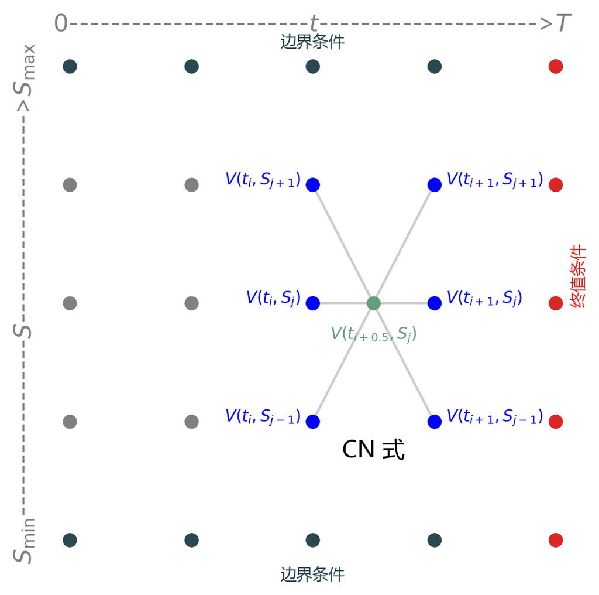

```python
ax = plot_grid_withTCBC( S_arr, t_arr )

size=10
dt = t_arr[1]-t_arr[0]
dS = S_arr[1]-S_arr[0]

(i,j) = (2,2)
(ti,Sj) = (t_arr[i], S_arr[j])
ax.plot( [ti, ti+dt], [Sj, Sj], color='k', alpha=0.2, zorder=0 )
ax.plot( [ti, ti+dt], [Sj-dS, Sj+dS], color='k', alpha=0.2, zorder=0 )
ax.plot( [ti, ti+dt], [Sj+dS, Sj-dS], color='k', alpha=0.2, zorder=0 )

ax.scatter(ti+0.5*dt, Sj, facecolor=g_hex, s=60, edgecolors=None, zorder=1 )

ax.scatter(ti, Sj, facecolor=g_hex, s=60, edgecolors=None, zorder=1 )
ax.scatter(ti, Sj-dS, facecolor='b', s=60, edgecolors=None, zorder=1 )
ax.scatter(ti, Sj+dS, facecolor='b', s=60, edgecolors=None, zorder=1 )
ax.scatter(ti, Sj, facecolor='b', s=60, edgecolors=None, zorder=1 )
ax.scatter(ti+dt, Sj-dS, facecolor='b', s=60, edgecolors=None, zorder=1 )
ax.scatter(ti+dt, Sj+dS, facecolor='b', s=60, edgecolors=None, zorder=1 )
ax.scatter(ti+dt, Sj, facecolor='b', s=60, edgecolors=None, zorder=1 )

ax.text( ti+0.5*dt, Sj-1.3*dS, 'CN 式', ha='center', size=14 )


ax.text( ti+0.5*dt, Sj-0.3*dS, '$V(t_{i+0.5}, S_{j})$', ha='center', color=g_hex, size=10, zorder=1 )
ax.text( ti-0.1*dt, Sj-dS, '$V(t_i, S_{j-1})$', ha='right', color='b', size=size )
ax.text( ti-0.1*dt, Sj, '$V(t_i, S_j)$', ha='right', color='b', size=size )
ax.text( ti-0.1*dt, Sj+dS, '$V(t_i, S_{j+1})$', ha='right', color='b', size=size )
ax.text( ti+1.1*dt, Sj-dS, '$V(t_{i+1}, S_{j-1})$', ha='left', color='b', size=size )
ax.text( ti+1.1*dt, Sj, '$V(t_{i+1}, S_j)$', ha='left', color='b', size=size )
ax.text( ti+1.1*dt, Sj+dS, '$V(t_{i+1}, S_{j+1})$', ha='left', color='b', size=size )

plt.show()
```

```python
class OptionPricingMethod():

    def __init__(self, S, K, r, q, T, sigma, option_type):
        self.S = S
        self.K = K
        self.r = r
        self.q = q
        self.T = T
        self.sigma = sigma
        self.option_type = option_type
        self.is_call = (option_type[0].lower()=='c')
        self.omega = 1 if self.is_call else -1
```

```python
(S, K, r, q, T, sigma, option_type) = (50, 50, 0.1, 0, 5/12, 0.4, 'put')
opt = OptionPricingMethod(S, K, r, q, T, sigma, option_type)
opt.T
```

```
0.4166666666666667
```

```python
import scipy.interpolate as spi
```

```python
class FiniteDifference(OptionPricingMethod):

    def __init__(self, S, K, r, q, T, sigma, option_type, Smin, Smax, Ns, Nt):
        super().__init__(S, K, r, q, T, sigma, option_type)
        self.Smin = Smin
        self.Smax = Smax
        self.Ns = int(Ns)
        self.Nt = int(Nt)
        self.dS = (Smax-Smin)/Ns * 1.0
        self.dt = T/Nt*1.0
        self.Svec = np.linspace(Smin, Smax, self.Ns+1)
        self.Tvec = np.linspace(0, T, self.Nt+1)
        self.grid = np.zeros(shape=(self.Ns+1, self.Nt+1))

    def _set_terminal_condition_(self):
        self.grid[:, -1] = np.maximum(self.omega*(self.Svec - self.K), 0)

    def _set_boundary_condition_(self):
        tau = self.Tvec[-1] - self.Tvec;
        DFq = np.exp(-q*tau)
        DFr = np.exp(-r*tau);

        self.grid[0,  :] = np.maximum(self.omega*(self.Svec[0]*DFq - self.K*DFr), 0)
        self.grid[-1, :] = np.maximum(self.omega*(self.Svec[-1]*DFq - self.K*DFr), 0)

    def _set_coefficient__(self):
        drift = (self.r-self.q)*self.Svec[1:-1]/self.dS
        diffusion_square = (self.sigma*self.Svec[1:-1]/self.dS)**2

        self.l = 0.5*(diffusion_square - drift)
        self.c = -diffusion_square - self.r
        self.u = 0.5*(diffusion_square + drift)

    def _solve_(self):
        pass

    def _interpolate_(self):
        tck = spi.splrep( self.Svec, self.grid[:,0], k=3 )
        return spi.splev( self.S, tck )
        #return np.interp(self.S, self.Svec, self.grid[:,0])

    def price(self):
        self._set_terminal_condition_()
        self._set_boundary_condition_()
        self._set_coefficient__()
        self._set_matrix_()
        self._solve_()
        return self._interpolate_()
```

```python
class FullyExplicitEu(FiniteDifference):

    def _set_matrix_(self):
        self.A = sp.diags([self.l[1:], self.c, self.u[:-1]], [-1, 0, 1],  format='csc')
        self.I = sp.eye(self.Ns-1)
        self.M = self.I + self.dt*self.A

    def _solve_(self):
        for j in reversed(np.arange(self.Nt)):
            U = self.M.dot(self.grid[1:-1, j+1])
            U[0] += self.l[0]*self.dt*self.grid[0, j+1]
            U[-1] += self.u[-1]*self.dt*self.grid[-1, j+1]
            self.grid[1:-1, j] = U
```

```python
(S, K, r, q, T, sigma, option_type) = (50, 50, 0.1, 0, 5/12, 0.4, 'put')
(Smin, Smax, Ns, Nt) = (0, 100, 100, 1000)

option = FullyExplicitEu(S, K, r, q, T, sigma, option_type, Smin, Smax, Ns, Nt)
print(option.price())
```

```
4.072882278148034
```

和解析解的结果比较，差别很小。

```python
omega = 1 if option_type[0].lower()=='c' else -1
blackscholes(S, K, r, q, T, sigma, omega)
```

```
4.075980984787781
```

当设定 `Ns = Nt = 100` 时

```python
option1 = FullyExplicitEu(S, K, r, q, T, sigma, option_type, Smin, Smax, 100, 100)
print(option1.price())
```

```
-1.6291077072266839e+53
```

显式方法的结果不稳定，当 $\Delta t$ 设定的过大，计算的期权价值不合理。

```python
class FullyImplicitEu(FiniteDifference):

    def _set_matrix_(self):
        self.A = sp.diags([self.l[1:], self.c, self.u[:-1]], [-1, 0, 1],  format='csc')
        self.I = sp.eye(self.Ns-1)
        self.M = self.I - self.dt*self.A

    def _solve_(self):
        _, M_lower, M_upper = sla.lu(self.M.toarray())

        for j in reversed(np.arange(self.Nt)):
            U = self.grid[1:-1, j+1].copy()
            U[0] += self.l[0]*self.dt*self.grid[0, j]
            U[-1] += self.u[-1]*self.dt*self.grid[-1, j]
            Ux = sla.solve_triangular( M_lower, U, lower=True )
            self.grid[1:-1, j] = sla.solve_triangular( M_upper, Ux, lower=False )
```

当设定 `Ns = 100, Nt = 1000` 或 `Ns = Nt = 100` 时，隐式法计算出来的结果很稳定。

```python
option2 = FullyImplicitEu(S, K, r, q, T, sigma, option_type, Smin, Smax, Ns, Nt)
print(option2.price())
```

```
4.071594188050028
```

```python
option2 = FullyImplicitEu(S, K, r, q, T, sigma, option_type, Smin, Smax, 100, 100)
print(option2.price())
```

```
4.065801939431444
```

```python
class CrankNicolsonEu(FiniteDifference):

    theta = 0.5

    def _set_matrix_(self):
        self.A = sp.diags([self.l[1:], self.c, self.u[:-1]], [-1, 0, 1],  format='csc')
        self.I = sp.eye(self.Ns-1)
        self.M1 = self.I + (1-self.theta)*self.dt*self.A
        self.M2 = self.I - self.theta*self.dt*self.A

    def _solve_(self):
        _, M_lower, M_upper = sla.lu(self.M2.toarray())
        for j in reversed(np.arange(self.Nt)):

            U = self.M1.dot(self.grid[1:-1, j+1])

            U[0] += self.theta*self.l[0]*self.dt*self.grid[0, j] \
                 + (1-self.theta)*self.l[0]*self.dt*self.grid[0, j+1]
            U[-1] += self.theta*self.u[-1]*self.dt*self.grid[-1, j] \
                  + (1-self.theta)*self.u[-1]*self.dt*self.grid[-1, j+1]

            Ux = sla.solve_triangular( M_lower, U, lower=True )
            self.grid[1:-1, j] = sla.solve_triangular( M_upper, Ux, lower=False )
```

```python
option3 = CrankNicolsonEu(S, K, r, q, T, sigma, option_type, Smin, Smax, Ns, Nt)
print(option3.price())
```

```
4.072238354486894
```

```python
option3 = CrankNicolsonEu(S, K, r, q, T, sigma, option_type, Smin, Smax, 100, 100)
print(option3.price())
```

```
4.072254507998125
```

### 有限差分求解可视化 1

```python
(S, K, r, q, T, sigma, option_type) = (50, 60, 0.03, 0.01, 1, 0.4, 'put')
(Smin, Smax, Ns, Nt) = (0, 4*np.maximum(S,K), 4, 4)
opt = FullyImplicitEu( S, K, r, q, T, sigma, option_type, Smin, Smax, Ns, Nt )
print(opt.price())
```

```
12.785582355111856
```

```python
import matplotlib.ticker as ticker
from mpl_toolkits.mplot3d import Axes3D

def PDE_visualizer( option, step=0 ):
    V0 = option.price()
    (Tvec, Svec, Vmat) = (option.Tvec, option.Svec, option.grid)

    (S0, K, r, q, omega) = (option.S, option.K, option.r, option.q, option.omega)

    fig = plt.figure(figsize=(6,4), dpi=100)
    ax = Axes3D(fig)

    t, S = np.meshgrid(Tvec, Svec)
    V = np.zeros(Vmat.shape)

    ax.scatter( t, S, V, color='k', alpha=0.2 )

    # 设定横轴和纵轴的范围
    ax.set_xlim3d(Tvec[0], Tvec[-1])
    ax.set_ylim3d(Svec[0], Svec[-1])
    ax.set_zlim3d(0, np.max(Vmat[:,-1]))

    # 设定标题和纵轴的标注
    ax.set_xlabel('时间', color=dt_hex)
    ax.set_ylabel('标的', color=r_hex)
    ax.set_zlabel('期权', color=g_hex)

    # 去除横轴和纵轴的刻度
    ax.set_xticks(Tvec)
    ax.set_xticklabels(['$t_0$', '$t_1$', '$t_2$', '$t_3$', '$t_4$'] )
    ax.set_yticks(Svec)
    ax.set_yticklabels(['$S_0$', '$S_1$', '$S_2$', '$S_3$', '$S_4$'] )
    ax.set_zticks([])

    ax.grid(False)

    # 给边界条件和终止条件的点上颜色，并标注
    DFq = np.exp(-q*(Tvec[-1]-Tvec))
    DFr = np.exp(-r*(Tvec[-1]-Tvec))

    LB = np.maximum(omega*(Svec[0]*DFq - K*DFr), 0)
    UB = np.maximum(omega*(Svec[-1]*DFq - K*DFr), 0)
    payoff = np.maximum(omega*(Svec-K),0)

    ax.plot( Tvec, S[0,:], LB, color=dt_hex )
    ax.scatter( Tvec, S[0,:], LB, color=dt_hex )

    ax.plot( Tvec, S[-1,:], UB, color=dt_hex )
    ax.scatter( Tvec, S[-1,:], UB, color=dt_hex )

    for i in reversed(np.arange(step,len(Tvec))):
        c = r_hex if i == len(Tvec)-1 else g_hex
        ax.plot( t[:,i], Svec, Vmat[:,i], color=c )
        ax.scatter( t[:,i], Svec, Vmat[:,i], color=c )

    if step == 0:
        ax.plot( [0], [S0], [V0], markerfacecolor='b', markeredgecolor='b', marker='o', markersize=8 )
```

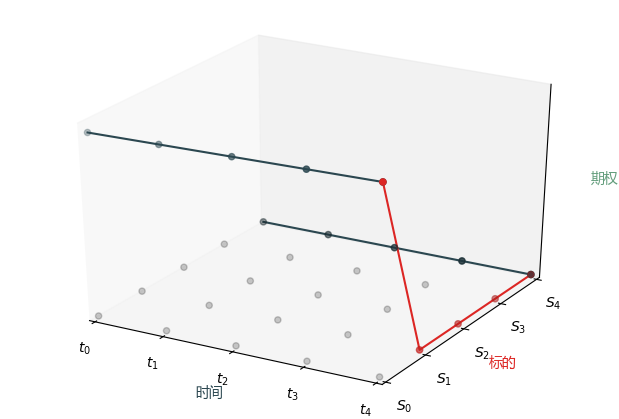

```python
PDE_visualizer( opt, 4 )
```

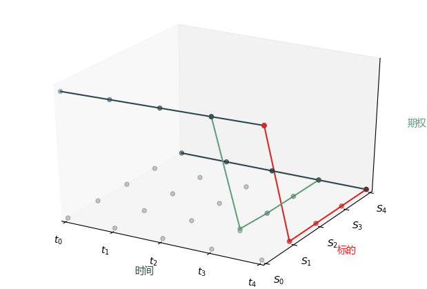

```python
PDE_visualizer( opt, 3 )
```

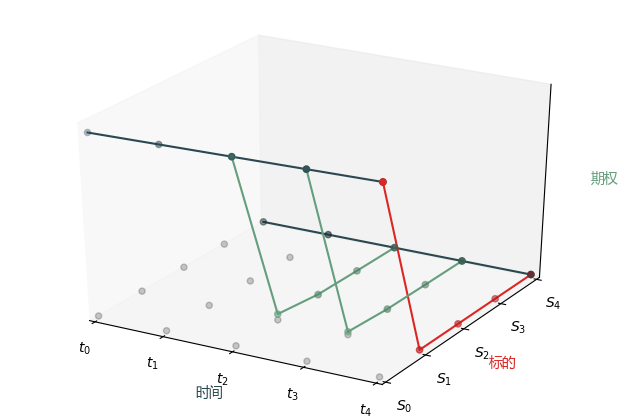

```python
PDE_visualizer( opt, 2 )
```

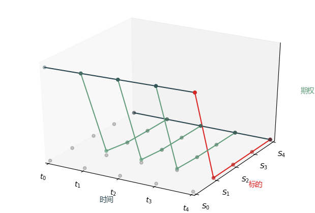

```python
PDE_visualizer( opt, 1 )
```

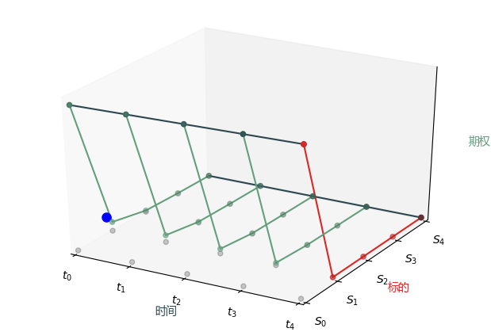

```python
PDE_visualizer( opt, 0 )
```

### 有限差分求解可视化 2

```python
(S, K, r, q, T, sigma, option_type) = (50, 60, 0.03, 0.01, 1, 0.4, 'put')
(Smin, Smax, Ns, Nt) = (0, 4*np.maximum(S,K), 1000, 1000)
opt = FullyImplicitEu( S, K, r, q, T, sigma, option_type, Smin, Smax, Ns, Nt )
print(opt.price())
```

```
13.582279662692397
```

```python
omega = 1 if option_type[0].lower()=='c' else -1
blackscholes(S, K, r, q, T, sigma, omega)
```

```
13.583200733417277
```

```python
from mpl_toolkits.mplot3d import Axes3D

def plot_surface( func, S, K, r, q, T, sigma, option_type, Smin, Smax, Ns, Nt ):
    fig = plt.figure(figsize=(8,4), dpi=120)
    ax = Axes3D(fig)

    option = func( S, K, r, q, T, sigma, option_type, Smin, Smax, Ns, Nt )
    V = option.price()

    Tgrid, Sgrid = np.meshgrid(option.Tvec, option.Svec)
    ax.plot_surface( Tgrid, Sgrid, option.grid, cmap='coolwarm', antialiased=False, alpha=0.5 )
    ax.plot( [0], [S], [V], markerfacecolor='k', markeredgecolor='k', marker='o', markersize=5 )
    ax.set_xlabel('时间')
    ax.set_ylabel('股价')
    ax.set_zlabel('期权价格')
    ax.view_init(elev=30, azim=160)

    plt.show()
```

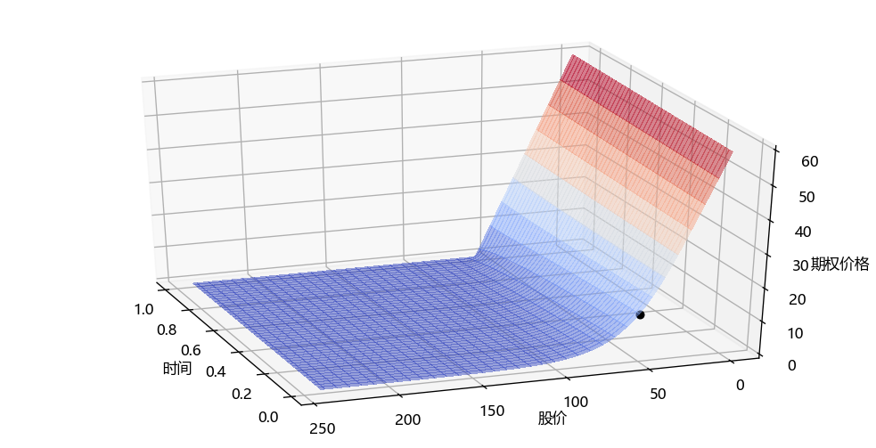

```python
plot_surface( FullyImplicitEu, S, K, r, q, T, sigma, option_type, Smin, Smax, 100, 1000)
```

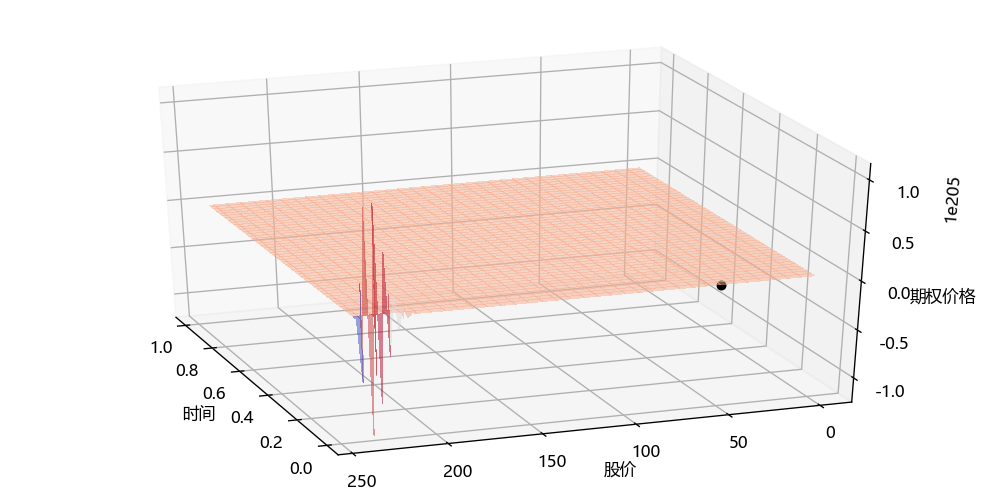

```python
plot_surface( FullyExplicitEu, S, K, r, q, T, sigma, option_type, Smin, Smax, 100, 1000)
```

检查有限差分的结果是否收敛。

```python
def convergence_test( func, S, K, r, q, T, sigma, option_type, Smin, Smax, Ns_vec, Nt_vec ):
    numerical = np.array([])
    for Ns, Nt in zip(Ns_vec, Nt_vec):
        option = func( S, K, r, q, T, sigma, option_type, Smin, Smax, Ns, Nt )
        numerical = np.append(numerical, option.price())

    omega = 1 if option_type[0].lower()=='c' else -1
    benchmark = blackscholes(S, K, r, q, T, sigma, omega)
    error = np.abs(numerical-benchmark)
    return error, benchmark, numerical
```

```python
Ns_vec = np.array([100, 200, 400, 800])
Nt_vec = np.array([200, 400, 800, 1600])
errorImp, impPrice, anaPrice = convergence_test( FullyImplicitEu, S, K, r, q, T, sigma, option_type, Smin, Smax, Ns_vec, Nt_vec )
errorCN, CNPrice, anaPrice = convergence_test( CrankNicolsonEu, S, K, r, q, T, sigma, option_type, Smin, Smax, Ns_vec, Nt_vec )
```

[figure not shown]

```python
fig = plt.figure(figsize=(8,4), dpi=120)
ax = fig.gca()

ax.plot( np.log(Nt_vec), errorImp, color=dt_hex, alpha=0.5, label='隐式法' )
ax.scatter( np.log(Nt_vec), errorImp, color =dt_hex )
ax.plot( np.log(Nt_vec), errorCN, color=r_hex, alpha=0.5, label='克兰克尼克尔森法' )
ax.scatter( np.log(Nt_vec), errorCN, color =r_hex )

ax.set_xticks(np.log(Nt_vec))
ax.set_xticklabels(['ln(100)', 'ln(200)', 'ln(400)', 'ln(800)', 'ln(1600)'])
ax.set_xlabel('ln(时段数)')
ax.set_ylabel('绝对差异')
ax.set_title('有限差分数值解 Vs 解析解')
plt.legend()
plt.show()
```

# 6. 线性回归

回到目录

SciPy 中可以做很多科学计算，但在统计计算上，`statsmodels` 模块可作为 SciPy 的延伸版。该工具包最主要的功能包括，统计测试和统计建模，包括线性回归 (linear regression)，对率回归 (logistic regression) 和时间序列分析 (time-series analysis)。

首先引入三个子工具包，分别用于通用功能、公式计算和画图，起名为 `sm`, `smf` 和 `smg`。

```python
import statsmodels.api as sm
import statsmodels.formula.api as smf
import statsmodels.graphics.api as smg
```

### 6.1 简单例子

回到章首

给定变量 $y = [1, 2, 3, 4, 5]$ 和自变量 $x_1 = [6, 7, 8, 9, 10]$ 和 $x_2 = [11, 12, 13, 14, 15]$，拟合线性模型 $y = \beta_0 + \beta_1 x_1+\beta_2 x_1 + \beta_3 x_1x_2$

```python
y = np.array([1, 2, 3, 4, 5])
x1 = np.array([6, 7, 8, 9, 10])
x2 = np.array([11, 12, 13, 14, 15])
X = np.vstack([np.ones(5), x1, x2, x1*x2]).T
```

我们可用 `sm.OLS` 来做拟合，注意 `OLS` 要大写。函数中的两个参数分别是变量和自变量。

```python
model = sm.OLS(y, X)
model
```

```
<statsmodels.regression.linear_model.OLS at 0x138b49976d8>
```

```python
result = model.fit()
```

```python
result.params
```

```
array([-5.55555556e-01,  1.88888889e+00, -8.88888889e-01, -1.11022302e-15])
```

我们还可用 `smf.ols` 来做拟合，注意 `ols` 要小写。函数中两个参数分别是**公式**和**数据帧**，其中数据帧的列标签和公式中的符号吻合。

```python
var = ['y', '1', 'x1', 'x2', 'x1:x2']
data = np.vstack([y, np.ones(5), x1, x2, x1*x2]).T
df = pd.DataFrame( data, columns=var )
df
```

|  | y | 1 | x1 | x2 | x1:x2 |
| --- | --- | --- | --- | --- | --- |
| 0 | 1.0 | 1.0 | 6.0 | 11.0 | 66.0 |
| 1 | 2.0 | 1.0 | 7.0 | 12.0 | 84.0 |
| 2 | 3.0 | 1.0 | 8.0 | 13.0 | 104.0 |
| 3 | 4.0 | 1.0 | 9.0 | 14.0 | 126.0 |
| 4 | 5.0 | 1.0 | 10.0 | 15.0 | 150.0 |

```python
model = smf.ols("y ~ 1 + x1 + x2 + x1:x2", df)
model
```

```
<statsmodels.regression.linear_model.OLS at 0x138b1fd4a90>
```

```python
result = model.fit()
```

```python
result.params
```

```
Intercept   -5.555556e-01
x1           1.888889e+00
x2          -8.888889e-01
x1:x2       -1.110223e-15
dtype: float64
```

```python
result.summary()
```

OLS Regression Results

| Dep. Variable: | y | R-squared: | 1.000 |
| --- | --- | --- | --- |
| Model: | OLS | Adj. R-squared: | 1.000 |
| Method: | Least Squares | F-statistic: | 7.401e+26 |
| Date: | Thu, 04 Jun 2020 | Prob (F-statistic): | 1.35e-27 |
| Time: | 14:15:15 | Log-Likelihood: | 145.84 |
| No. Observations: | 5 | AIC: | -285.7 |
| Df Residuals: | 2 | BIC: | -286.9 |
| Df Model: | 2 |  |  |
| Covariance Type: | nonrobust |  |  |

|  | coef | std err | t | P>\|t\| | [0.025 | 0.975] |
| --- | --- | --- | --- | --- | --- | --- |
| Intercept | -0.5556 | 1.87e-13 | -2.96e+12 | 0.000 | -0.556 | -0.556 |
| x1 | 1.8889 | 6.99e-13 | 2.7e+12 | 0.000 | 1.889 | 1.889 |
| x2 | -0.8889 | 2.38e-13 | -3.73e+12 | 0.000 | -0.889 | -0.889 |
| x1:x2 | -1.11e-15 | 2.2e-14 | -0.051 | 0.964 | -9.56e-14 | 9.34e-14 |

| Omnibus: | nan | Durbin-Watson: | 0.003 |
| --- | --- | --- | --- |
| Prob(Omnibus): | nan | Jarque-Bera (JB): | 0.645 |
| Skew: | 0.375 | Prob(JB): | 0.724 |
| Kurtosis: | 1.408 | Cond. No. | 9.62e+17 |

Warnings:  
[1] Standard Errors assume that the covariance matrix of the errors is correctly specified.  
[2] The smallest eigenvalue is 6.68e-32. This might indicate that there are  
strong multicollinearity problems or that the design matrix is singular.

### 6.2 金融案例

回到章首

### 资本资产定价模型 (Capital Asset Pricing Model, CAMP)

CAPM 是由威廉·夏普 (William Sharpe)、约翰·林特尔 (John Lintner)、杰克·特里诺 (Jack Treynor) 和简·莫辛 (Jan Mossin) 等人在现代投资组合理论的基础上发展起来的，对于一个给定的资产组合，它的期望回报率和市场投资组合的期望回报率之间的关系可以表示为：

\begin{equation} R_{p} = r + \beta_{\text{mkt}}(R_{\text{mkt}}-r) + \alpha \end{equation}

其中：

- $R_{p}$ 是投资组合的期望收益率
- $r$ 是市场无风险收益率
- $R_{\text{mkt}}$ 是市场组合的收益率，那么 $R_{\text{mkt}}-r$ 是市场组合风险溢价
- $\alpha$ 是超额收益率

```python
data = pd.read_csv('Factor Data.csv')
data.head(3).append(data.tail(3))
```

|  | Date | Portfolio | Market_Excess | SMB | HML | RMW | CMA | RF |
| --- | --- | --- | --- | --- | --- | --- | --- | --- |
| 0 | 03/01/2013 | -0.005066 | -0.0014 | 0.0014 | 0.0004 | 0.0020 | 0.0023 | 0.00000 |
| 1 | 04/01/2013 | 0.004024 | 0.0055 | 0.0019 | 0.0043 | -0.0037 | 0.0027 | 0.00000 |
| 2 | 07/01/2013 | 0.004421 | -0.0031 | -0.0009 | -0.0037 | -0.0013 | -0.0012 | 0.00000 |
| 1255 | 27/12/2017 | 0.001651 | 0.0005 | -0.0016 | -0.0019 | 0.0006 | -0.0012 | 0.00004 |
| 1256 | 28/12/2017 | 0.002317 | 0.0022 | 0.0010 | 0.0003 | -0.0009 | -0.0020 | 0.00004 |
| 1257 | 29/12/2017 | -0.006222 | -0.0057 | -0.0030 | 0.0002 | 0.0018 | 0.0014 | 0.00004 |

```python
data['Portfolio_Excess'] = data['Portfolio'] - data['RF']
data.head(3).append(data.tail(3))
```

|  | Date | Portfolio | Market_Excess | SMB | HML | RMW | CMA | RF | Portfolio_Excess |
| --- | --- | --- | --- | --- | --- | --- | --- | --- | --- |
| 0 | 03/01/2013 | -0.005066 | -0.0014 | 0.0014 | 0.0004 | 0.0020 | 0.0023 | 0.00000 | -0.005066 |
| 1 | 04/01/2013 | 0.004024 | 0.0055 | 0.0019 | 0.0043 | -0.0037 | 0.0027 | 0.00000 | 0.004024 |
| 2 | 07/01/2013 | 0.004421 | -0.0031 | -0.0009 | -0.0037 | -0.0013 | -0.0012 | 0.00000 | 0.004421 |
| 1255 | 27/12/2017 | 0.001651 | 0.0005 | -0.0016 | -0.0019 | 0.0006 | -0.0012 | 0.00004 | 0.001611 |
| 1256 | 28/12/2017 | 0.002317 | 0.0022 | 0.0010 | 0.0003 | -0.0009 | -0.0020 | 0.00004 | 0.002277 |
| 1257 | 29/12/2017 | -0.006222 | -0.0057 | -0.0030 | 0.0002 | 0.0018 | 0.0014 | 0.00004 | -0.006262 |

```python
CAPM = smf.ols('Portfolio_Excess ~ Market_Excess', data)
result = CAPM.fit()
result.summary()
```

OLS Regression Results

| Dep. Variable: | Portfolio_Excess | R-squared: | 0.794 |
| --- | --- | --- | --- |
| Model: | OLS | Adj. R-squared: | 0.794 |
| Method: | Least Squares | F-statistic: | 4854. |
| Date: | Thu, 04 Jun 2020 | Prob (F-statistic): | 0.00 |
| Time: | 15:28:21 | Log-Likelihood: | 5226.5 |
| No. Observations: | 1258 | AIC: | -1.045e+04 |
| Df Residuals: | 1256 | BIC: | -1.044e+04 |
| Df Model: | 1 |  |  |
| Covariance Type: | nonrobust |  |  |

|  | coef | std err | t | P>\|t\| | [0.025 | 0.975] |
| --- | --- | --- | --- | --- | --- | --- |
| Intercept | 0.0002 | 0.000 | 2.009 | 0.045 | 5.03e-06 | 0.000 |
| Market_Excess | 0.9738 | 0.014 | 69.669 | 0.000 | 0.946 | 1.001 |

| Omnibus: | 372.020 | Durbin-Watson: | 1.965 |
| --- | --- | --- | --- |
| Prob(Omnibus): | 0.000 | Jarque-Bera (JB): | 3087.179 |
| Skew: | 1.128 | Prob(JB): | 0.00 |
| Kurtosis: | 10.335 | Cond. No. | 130. |

Warnings:  
[1] Standard Errors assume that the covariance matrix of the errors is correctly specified.

```python
result.rsquared_adj
```

```
0.7942627173052246
```

```python
result.params
```

```
Intercept        0.000216
Market_Excess    0.973776
dtype: float64
```

CAMP 的 adjusted R^2 是 0.7943, 贝塔为 0.9738，说明该组合的回报绝大部分都可以被市场因子所解释。

### FF 三因子模型 (Fama-French 3 Factor Model, FF3FM)

CAMP 投资组合的全部风险溢价由市场贝塔表示，但该模型在解释股票市场回报的现实情况上遇到了诸多挑战。尤金·法玛 (Eugene Fama) 和肯尼斯·佛伦奇 (Kenneth French) 在 1992 年观察发现市值较小、账面市值比较高的两类公司更有可能取得优于市场水平的平均回报率。因此他们在 FF3FM 中又引入二个新的解释变量，**市净率 (Book-to-Market, BM)**、**公司规模 (size)**，与 CAPM 中的市场指数一同估计股票的回报水平，其公式为：

\begin{equation} R_{p} = r + \beta_{\text{mkt}}(R_{\text{mkt}}-r) + \beta_{\text{SMB}}R_{\text{SMB}} + \beta_{\text{HML}}R_{\text{HML}} + \alpha \end{equation}

其中：

- $R_{p}$ 是投资组合的期望收益率
- $r$ 是市场无风险收益率
- $R_{\text{mkt}}$ 是市场组合的收益率，那么 $R_{\text{mkt}}-r$ 是市场组合风险溢价
- $R_{\text{SMB}}$ 是规模溢价，SMB 代表 Small Minus Big，即**小市值公司股票组合回报**与**大市值公司股票组合回报**之差
- $R_{\text{HML}}$ 是市净率溢价，HML 代表 High Minus Low，即**账面价值高的公司股票组合回报**与**比账面价值低的公司股票组合回报**之差
- $\beta_{\text{mkt}}$ 是市场因子载荷
- $\beta_{\text{SMB}}$ 是规模因子载荷
- $\beta_{\text{HML}}$ 是市净率因子载荷
- $\alpha$ 是超额收益率

```python
FF3_model = smf.ols('Portfolio_Excess ~ Market_Excess + SMB + HML', data)
result = FF3_model.fit()
result.summary()
```

OLS Regression Results

| Dep. Variable: | Portfolio_Excess | R-squared: | 0.820 |
| --- | --- | --- | --- |
| Model: | OLS | Adj. R-squared: | 0.819 |
| Method: | Least Squares | F-statistic: | 1902. |
| Date: | Thu, 04 Jun 2020 | Prob (F-statistic): | 0.00 |
| Time: | 15:36:13 | Log-Likelihood: | 5309.4 |
| No. Observations: | 1258 | AIC: | -1.061e+04 |
| Df Residuals: | 1254 | BIC: | -1.059e+04 |
| Df Model: | 3 |  |  |
| Covariance Type: | nonrobust |  |  |

|  | coef | std err | t | P>\|t\| | [0.025 | 0.975] |
| --- | --- | --- | --- | --- | --- | --- |
| Intercept | 0.0002 | 0.000 | 1.820 | 0.069 | -1.43e-05 | 0.000 |
| Market_Excess | 1.0155 | 0.014 | 75.192 | 0.000 | 0.989 | 1.042 |
| SMB | -0.2622 | 0.021 | -12.432 | 0.000 | -0.304 | -0.221 |
| HML | -0.1087 | 0.021 | -5.065 | 0.000 | -0.151 | -0.067 |

| Omnibus: | 433.585 | Durbin-Watson: | 2.016 |
| --- | --- | --- | --- |
| Prob(Omnibus): | 0.000 | Jarque-Bera (JB): | 4429.286 |
| Skew: | 1.293 | Prob(JB): | 0.00 |
| Kurtosis: | 11.821 | Cond. No. | 217. |

Warnings:  
[1] Standard Errors assume that the covariance matrix of the errors is correctly specified.

```python
result.rsquared_adj
```

```
0.8193910057247713
```

FF3FM 的 adjusted R^2 从 CAPM 的 0.7943 增加到 0.8194。

```python
result.pvalues
```

```
Intercept        6.904128e-02
Market_Excess    0.000000e+00
SMB              1.520065e-33
HML              4.699343e-07
dtype: float64
```

```python
result.params
```

```
Intercept        0.000183
Market_Excess    1.015498
SMB             -0.262152
HML             -0.108657
dtype: float64
```

此外，规模因子载荷 $\beta_{\text{SMB}}$ 和市净率因子载荷 $\beta_{\text{HML}}$ 都为负，再回顾一下 SMB 和 HML 的定义：

```
SMB = 小市值公司 - 大市值公司
HML = 价值型公司 - 成长型公司
```

那么负 $\beta_{\text{SMB}} = -0.26$ 和 $\beta_{\text{HML}} = -0.11$ 意味着**大市值公司**和**成长型公司**在这段时间能能带来更高的风险和回报，虽然从历史上看**小市值公司**和**价值型公司**能带来更高的风险和回报。

### FF 五因子模型 (Fama-French 5 Factor Model, FF5FM)

FF5FM 在 FF3FM 基础上又加了盈利能力 (profitability) 因子和投资模式 (investment patterns) 因子，其公式为：

\begin{equation} R_{p} = r + \beta_{\text{mkt}}(R_{\text{mkt}}-r) + \beta_{\text{SMB}}R_{\text{SMB}} + \beta_{\text{HML}}R_{\text{HML}} + \beta_{\text{RMW}}R_{\text{RMW}} + \beta_{\text{CMA}}R_{\text{CMLA}}+ \alpha \end{equation}

其中

- $R_{p}$ 是投资组合的期望收益率
- $r$ 是市场无风险收益率
- $R_{\text{mkt}}$ 是市场组合的收益率，那么 $R_{\text{mkt}}-r$ 是市场组合风险溢价
- $R_{\text{SMB}}$ 是规模溢价，SMB 代表 Small Minus Big，即**小市值公司股票组合回报**与**大市值公司股票组合回报**之差
- $R_{\text{HML}}$ 是市净率溢价，HML 代表 High Minus Low，即**账面价值高的公司股票组合回报**与**比账面价值低的公司股票组合回报**之差
- $R_{\text{RMW}}$ 是规模溢价，RMW 代表 Robust Minus Weak，即**高盈利公司股票组合回报**与**低盈利公司股票组合回报**之差
- $R_{\text{CMA}}$ 是规模溢价，CMA 代表 Conservative Minus Aggressive，即**高投资比例公司股票组合回报**与**低投资比例公司股票组合回报**之差
- $\beta_{\text{mkt}}$ 是市场因子载荷
- $\beta_{\text{SMB}}$ 是规模因子载荷
- $\beta_{\text{HML}}$ 是市净率因子载荷
- $\beta_{\text{RMW}}$ 是盈利能力因子载荷
- $\beta_{\text{CMA}}$ 是投资模式因子载荷
- $\alpha$ 是超额收益率

```python
FF5_model = smf.ols('Portfolio_Excess ~ Market_Excess + SMB + HML + RMW + CMA', data)
result = FF5_model.fit()
result.summary()
```

OLS Regression Results

| Dep. Variable: | Portfolio_Excess | R-squared: | 0.837 |
| --- | --- | --- | --- |
| Model: | OLS | Adj. R-squared: | 0.837 |
| Method: | Least Squares | F-statistic: | 1289. |
| Date: | Thu, 04 Jun 2020 | Prob (F-statistic): | 0.00 |
| Time: | 15:57:01 | Log-Likelihood: | 5373.9 |
| No. Observations: | 1258 | AIC: | -1.074e+04 |
| Df Residuals: | 1252 | BIC: | -1.070e+04 |
| Df Model: | 5 |  |  |
| Covariance Type: | nonrobust |  |  |

|  | coef | std err | t | P>\|t\| | [0.025 | 0.975] |
| --- | --- | --- | --- | --- | --- | --- |
| Intercept | 0.0002 | 9.58e-05 | 1.819 | 0.069 | -1.37e-05 | 0.000 |
| Market_Excess | 0.9728 | 0.014 | 71.773 | 0.000 | 0.946 | 0.999 |
| SMB | -0.2739 | 0.021 | -13.049 | 0.000 | -0.315 | -0.233 |
| HML | 0.0714 | 0.026 | 2.727 | 0.006 | 0.020 | 0.123 |
| RMW | -0.0740 | 0.034 | -2.162 | 0.031 | -0.141 | -0.007 |
| CMA | -0.4685 | 0.042 | -11.132 | 0.000 | -0.551 | -0.386 |

| Omnibus: | 379.546 | Durbin-Watson: | 1.987 |
| --- | --- | --- | --- |
| Prob(Omnibus): | 0.000 | Jarque-Bera (JB): | 3276.700 |
| Skew: | 1.144 | Prob(JB): | 0.00 |
| Kurtosis: | 10.568 | Cond. No. | 486. |

Warnings:  
[1] Standard Errors assume that the covariance matrix of the errors is correctly specified.

```python
result.rsquared_adj
```

```
0.8367245013852503
```

FF5FM 的 adjusted R^2 从 FF3FM 的 0.8194 增加到 0.8367。

```python
result.pvalues
```

```
Intercept        6.918808e-02
Market_Excess    0.000000e+00
SMB              1.393412e-36
HML              6.482541e-03
RMW              3.084502e-02
CMA              1.633010e-27
dtype: float64
```

```python
result.params
```

```
Intercept        0.000174
Market_Excess    0.972762
SMB             -0.273882
HML              0.071427
RMW             -0.074011
CMA             -0.468463
dtype: float64
```

# Cheatsheet

[figure not shown]